# lab3

2026-03-11

# Link de GitHub:

https://github.com/can23384/Lab3_DM

```r
required_pkgs <- c(
  "tidyverse", "janitor", "skimr", "naniar", "GGally",
  "corrplot", "e1071", "factoextra", "cluster", "car", "scales"
)

new_pkgs <- required_pkgs[!(required_pkgs %in% installed.packages()[, "Package"])]
if(length(new_pkgs) > 0) install.packages(new_pkgs)

invisible(lapply(required_pkgs, library, character.only = TRUE))

theme_set(theme_minimal(base_size = 12))
options(scipen = 999)
set.seed(123)

tmp_env <- new.env()
objs <- load("listings.RData", envir = tmp_env)

df_candidates <- objs[sapply(objs, function(nm) {
  x <- tmp_env[[nm]]
  is.data.frame(x) || inherits(x, c("tbl_df", "data.table"))
})]

stopifnot(length(df_candidates) > 0)

sizes <- sapply(df_candidates, function(nm) {
  x <- as.data.frame(tmp_env[[nm]])
  nrow(x) * ncol(x)
})

raw_listings <- as_tibble(tmp_env[[df_candidates[which.max(sizes)]]]) %>%
  janitor::clean_names()

glimpse(raw_listings)
```

```
## Rows: 171,748
## Columns: 80
## $ id                                           <dbl> 5456, 6448, 8502, 13035, …
## $ listing_url                                  <chr> "https://www.airbnb.com/r…
## $ scrape_id                                    <dbl> 20250916040734, 202509160…
## $ last_scraped                                 <chr> "2025-09-17", "2025-09-17…
## $ source                                       <chr> "city scrape", "city scra…
## $ name                                         <chr> "Walk to 6th, Rainey St a…
## $ description                                  <chr> "Great central  location …
## $ neighborhood_overview                        <chr> "My neighborhood is ideal…
## $ picture_url                                  <chr> "https://a0.muscache.com/…
## $ host_id                                      <int> 8028, 14156, 25298, 50793…
## $ host_url                                     <chr> "https://www.airbnb.com/u…
## $ host_name                                    <chr> "Sylvia", "Amy", "Karen",…
## $ host_since                                   <chr> "2009-02-16", "2009-04-20…
```

[output cut: 67 more lines]

```r
parse_money <- function(x) {
  if (is.numeric(x)) return(x)
  readr::parse_number(as.character(x))
}

parse_percent01 <- function(x) {
  if (is.numeric(x)) return(x)
  readr::parse_number(as.character(x)) / 100
}

bool_to_factor <- function(x) {
  x_chr <- tolower(as.character(x))
  case_when(
    x_chr %in% c("t", "true", "yes", "1") ~ "Yes",
    x_chr %in% c("f", "false", "no", "0") ~ "No",
    TRUE ~ NA_character_
  ) %>% factor(levels = c("No", "Yes"))
}

safe_skew <- function(x) {
  x <- x[!is.na(x)]
  if (length(x) < 3) return(NA_real_)
  e1071::skewness(x, type = 2)
}

count_outliers_iqr <- function(x) {
  x <- x[!is.na(x)]
  if (length(x) < 4) return(NA_integer_)
  q1 <- quantile(x, 0.25, na.rm = TRUE)
  q3 <- quantile(x, 0.75, na.rm = TRUE)
  iqr <- q3 - q1
  sum(x < (q1 - 1.5 * iqr) | x > (q3 + 1.5 * iqr))
}

summarise_numeric <- function(data, vars) {
  map_dfr(vars, function(v) {
    x <- data[[v]]
    x2 <- x[!is.na(x)]

    if (length(x2) == 0) {
      return(tibble(
        variable = v, n = 0, mean = NA_real_, median = NA_real_,
        sd = NA_real_, min = NA_real_, p01 = NA_real_, p25 = NA_real_,
        p75 = NA_real_, p99 = NA_real_, max = NA_real_,
        skew = NA_real_, outliers_iqr = NA_integer_
      ))
    }

    tibble(
      variable = v,
      n = length(x2),
      mean = mean(x2),
      median = median(x2),
      sd = sd(x2),
      min = min(x2),
      p01 = quantile(x2, 0.01),
      p25 = quantile(x2, 0.25),
      p75 = quantile(x2, 0.75),
      p99 = quantile(x2, 0.99),
      max = max(x2),
      skew = safe_skew(x2),
      outliers_iqr = count_outliers_iqr(x2)
    )
  })
}
```

# Descripción general del dataset

```r
listings <- raw_listings

# Conversión básica de formatos
if ("price" %in% names(listings)) {
  listings <- listings %>% mutate(price = parse_money(price))
}

percent_cols <- intersect(c("host_response_rate", "host_acceptance_rate"), names(listings))
if (length(percent_cols) > 0) {
  listings <- listings %>% mutate(across(all_of(percent_cols), parse_percent01))
}

date_cols <- intersect(
  c("last_scraped", "calendar_last_scraped", "host_since", "first_review", "last_review"),
  names(listings)
)
if (length(date_cols) > 0) {
  listings <- listings %>% mutate(across(all_of(date_cols), ~ suppressWarnings(as.Date(.x))))
}

if ("bathrooms_text" %in% names(listings)) {
  listings <- listings %>%
    mutate(
      bathrooms_text_num = readr::parse_number(bathrooms_text),
      bathrooms = if ("bathrooms" %in% names(listings)) coalesce(bathrooms, bathrooms_text_num) else bathrooms_text_num
    )
}

# Detectar binarias t/f, yes/no, etc.
bool_candidates <- names(listings)[sapply(listings, function(x) {
  vals <- unique(tolower(as.character(stats::na.omit(x))))
  length(vals) > 0 && all(vals %in% c("t", "f", "true", "false", "yes", "no", "0", "1"))
})]

if (length(bool_candidates) > 0) {
  listings <- listings %>% mutate(across(all_of(bool_candidates), bool_to_factor))
}

# Algunas variables deberían tratarse como categóricas
cat_code_cols <- intersect(
  c("neighbourhood_cleansed", "neighbourhood_group_cleansed", "property_type", "room_type", "city"),
  names(listings)
)
if (length(cat_code_cols) > 0) {
  listings <- listings %>% mutate(across(all_of(cat_code_cols), as.factor))
}

dataset_overview <- tibble(
  filas = nrow(listings),
  columnas = ncol(listings),
  variable_objetivo = "price"
)

dataset_overview
```

```
## # A tibble: 1 × 3
##    filas columnas variable_objetivo
##    <int>    <int> <chr>
## 1 171748       81 price
```

El conjunto de datos utilizado para el análisis exploratorio contiene 171,748 observaciones y 81 variables, por lo que se trata de una base suficientemente grande y rica para desarrollar un modelo predictivo. La variable objetivo seleccionada es price, ya que representa el precio del alojamiento y constituye la variable de interés del problema de predicción. En términos generales, la estructura del dataset combina variables numéricas, categóricas, fechas y campos de texto, lo cual permite explorar tanto características del alojamiento como atributos del anfitrión, disponibilidad, reseñas y ubicación

# Calidad de datos y preprocesamiento

```r
quality_tbl <- tibble(
  variable   = names(listings),
  clase      = map_chr(listings, ~ class(.x)[1]),
  n_missing  = map_int(listings, ~ sum(is.na(.x))),
  pct_missing = map_dbl(listings, ~ mean(is.na(.x))),
  n_unicos   = map_int(listings, ~ n_distinct(.x, na.rm = TRUE))
) %>%
  mutate(pct_unicos = n_unicos / nrow(listings)) %>%
  arrange(desc(pct_missing), desc(pct_unicos))

quality_tbl %>% slice_head(n = 30)
```

```
## # A tibble: 30 × 6
##    variable                     clase  n_missing pct_missing n_unicos pct_unicos
##    <chr>                        <chr>      <int>       <dbl>    <int>      <dbl>
##  1 calendar_updated             logic…    171748       1            0  0
##  2 estimated_revenue_l365d      integ…     95502       0.556     9746  0.0567
##  3 price                        numer…     95502       0.556     2320  0.0135
##  4 neighbourhood_group_cleansed factor     50683       0.295       17  0.0000990
##  5 review_scores_value          numer…     40328       0.235      187  0.00109
##  6 review_scores_location       numer…     40328       0.235      184  0.00107
##  7 review_scores_checkin        numer…     40324       0.235      152  0.000885
##  8 review_scores_accuracy       numer…     40312       0.235      171  0.000996
##  9 review_scores_communication  numer…     40308       0.235      161  0.000937
## 10 review_scores_cleanliness    numer…     40302       0.235      195  0.00114
## # ℹ 20 more rows
```

```r
duplicate_rows <- sum(duplicated(listings))
duplicate_id <- if ("id" %in% names(listings)) sum(duplicated(listings$id)) else NA_integer_

tibble(
  duplicados_fila = duplicate_rows,
  duplicados_id = duplicate_id
)
```

```
## # A tibble: 1 × 2
##   duplicados_fila duplicados_id
##             <int>         <int>
## 1               0             0
```

```r
constant_cols <- quality_tbl %>%
  filter(n_unicos <= 1 | pct_missing == 1) %>%
  pull(variable)

id_like_cols <- names(listings)[str_detect(names(listings), "(^id$|_id$|_url$|^url$|picture|thumbnail|scrape_id)")]

text_like_cols <- intersect(
  c("name", "description", "neighborhood_overview", "host_about",
    "bathrooms_text", "listing_url", "host_url", "picture_url",
    "host_picture_url", "host_thumbnail_url"),
  names(listings)
)

high_card_cols <- quality_tbl %>%
  filter(clase %in% c("character", "factor"), pct_unicos > 0.40) %>%
  pull(variable)

drop_candidates <- unique(c(
  constant_cols,
  id_like_cols,
  text_like_cols,
  high_card_cols
))

action_tbl <- tibble(variable = drop_candidates) %>%
  mutate(
    razon = case_when(
      variable %in% constant_cols ~ "Constante o completamente vacía",
      variable %in% id_like_cols ~ "ID / URL / imagen",
      variable %in% text_like_cols ~ "Texto libre o columna no estructurada",
      variable %in% high_card_cols ~ "Alta cardinalidad",
      TRUE ~ "Revisar manualmente"
    )
  ) %>%
  arrange(razon, variable)

action_tbl
```

```
## # A tibble: 15 × 2
##    variable              razon
##    <chr>                 <chr>
##  1 amenities             Alta cardinalidad
##  2 calendar_updated      Constante o completamente vacía
##  3 host_id               ID / URL / imagen
##  4 host_picture_url      ID / URL / imagen
##  5 host_thumbnail_url    ID / URL / imagen
##  6 host_url              ID / URL / imagen
##  7 id                    ID / URL / imagen
##  8 listing_url           ID / URL / imagen
##  9 picture_url           ID / URL / imagen
## 10 scrape_id             ID / URL / imagen
## 11 bathrooms_text        Texto libre o columna no estructurada
## 12 description           Texto libre o columna no estructurada
## 13 host_about            Texto libre o columna no estructurada
## 14 name                  Texto libre o columna no estructurada
## 15 neighborhood_overview Texto libre o columna no estructurada
```

```r
# Dataset para EDA/modelado inicial
listings_clean <- listings %>%
  select(-any_of(drop_candidates)) %>%
  distinct()

# Agregar log_price si aplica
if ("price" %in% names(listings_clean)) {
  listings_clean <- listings_clean %>%
    mutate(log_price = if_else(price > 0, log(price), NA_real_))
}

glimpse(listings_clean)
```

```
## Rows: 170,127
## Columns: 67
## $ last_scraped                                 <date> 2025-09-17, 2025-09-17, …
## $ source                                       <chr> "city scrape", "city scra…
## $ host_name                                    <chr> "Sylvia", "Amy", "Karen",…
## $ host_since                                   <date> 2009-02-16, 2009-04-20, …
## $ host_location                                <chr> "Austin, TX", "Austin, TX…
## $ host_response_time                           <chr> "within a few hours", "wi…
## $ host_response_rate                           <dbl> 1.00, 1.00, 1.00, 1.00, 1…
## $ host_acceptance_rate                         <dbl> 0.90, 0.96, 0.60, 0.91, 0…
## $ host_is_superhost                            <chr> "t", "t", "f", "t", "t", …
## $ host_neighbourhood                           <chr> "East Downtown", "Zilker"…
## $ host_listings_count                          <int> 1, 1, 1, 2, 1, 1, 1, 1, 1…
## $ host_total_listings_count                    <int> 2, 2, 1, 2, 1, 1, 2, 2, 2…
## $ host_verifications                           <chr> "['email', 'phone']", "['…
```

[output cut: 54 more lines]

En la etapa de preprocesamiento se identificó que varias variables requerían transformación de formato. En particular, price se encontraba originalmente como texto con símbolo monetario y fue convertida a formato numérico. De forma similar, las tasas de respuesta y aceptación del anfitrión fueron transformadas desde porcentajes a proporciones, mientras que variables temporales como host_since, last_review y calendar_last_scraped fueron convertidas a tipo fecha. También se generó una versión numérica de bathrooms_text, con el fin de complementar la variable bathrooms cuando fuera necesario. Durante este proceso aparecieron fallos de parseo asociados a valores como N/A en porcentajes y descripciones no estándar como “Half-bath” en baños, lo que sugiere que parte de la información original tenía formatos heterogéneos y debía tratarse con cautela.

En cuanto a calidad de datos, no se detectaron filas duplicadas ni IDs duplicados, lo que indica consistencia estructural en los registros. Sin embargo, sí se observaron variables con una alta proporción de faltantes. Destaca el caso de price y estimated_revenue_l365d, ambas con 95,502 valores faltantes, equivalentes a aproximadamente 55.6% del total. También aparecen faltantes relevantes en neighbourhood_group_cleansed y en varias variables de calificaciones (review_scores_*). Por esta razón, el análisis posterior de la variable respuesta se realiza únicamente sobre observaciones con precio disponible.

Además, se eliminaron columnas consideradas poco útiles para un modelo predictivo inicial, especialmente variables tipo ID, URL, imágenes, texto libre y columnas constantes, ya que no aportan información directa o introducen ruido innecesario. Entre ellas se encuentran id, host_id, listing_url, picture_url, description, host_about, name y calendar_updated. Tras esta depuración y eliminación de duplicados, el dataset de trabajo quedó con 170,127 filas y 67 columnas, una estructura más adecuada para el EDA y para etapas posteriores de modelado

# Análisis univariado

## Numéricas

```r
num_vars <- listings_clean %>%
  select(where(is.numeric)) %>%
  names()

numeric_summary <- summarise_numeric(listings_clean, num_vars) %>%
  arrange(desc(outliers_iqr))

numeric_summary
```

```
## # A tibble: 44 × 13
##    variable         n    mean median      sd   min   p01   p25   p75   p99   max
##    <chr>        <int>   <dbl>  <dbl>   <dbl> <dbl> <dbl> <dbl> <dbl> <dbl> <dbl>
##  1 host_respo… 135723   0.957   1    1.55e-1     0     0  1        1     1     1
##  2 calculated… 170127  38.8     1    1.30e+2     0     0  1       12   612  1189
##  3 host_total… 169256 255.      6    1.05e+3     0     1  2       40  6053 10050
##  4 host_listi… 169256 178.      4    7.74e+2     0     1  1       29  5246  5531
##  5 number_of_… 170127   7.89    0    1.75e+1     0     0  0        7    71  1797
##  6 calculated… 170127  45.0     3    1.34e+2     1     1  1       20   612  1189
##  7 calculated… 170127   5.50    0    3.76e+1     0     0  0        1   132   567
##  8 number_of_… 170127  44.4     9    9.03e+1     0     0  1       47   435  3920
##  9 number_of_… 170127   8.87    1    1.80e+1     0     0  0       11    70  1565
## 10 host_accep… 139073   0.858   0.98 2.44e-1     0     0  0.84     1     1     1
## # ℹ 34 more rows
## # ℹ 2 more variables: skew <dbl>, outliers_iqr <int>
```

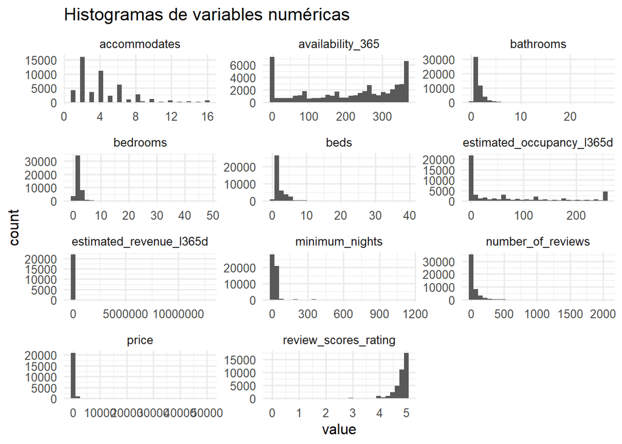

```r
key_num <- intersect(
  c("price", "accommodates", "bathrooms", "bedrooms", "beds",
    "minimum_nights", "number_of_reviews", "review_scores_rating",
    "availability_365", "estimated_occupancy_l365d", "estimated_revenue_l365d"),
  names(listings_clean)
)

plot_sample <- listings_clean %>%
  select(all_of(key_num)) %>%
  slice_sample(n = min(50000, nrow(listings_clean)))

plot_sample %>%
  pivot_longer(cols = everything(), names_to = "variable", values_to = "value") %>%
  ggplot(aes(x = value)) +
  geom_histogram(bins = 30) +
  facet_wrap(~ variable, scales = "free", ncol = 3) +
  labs(title = "Histogramas de variables numéricas")
```

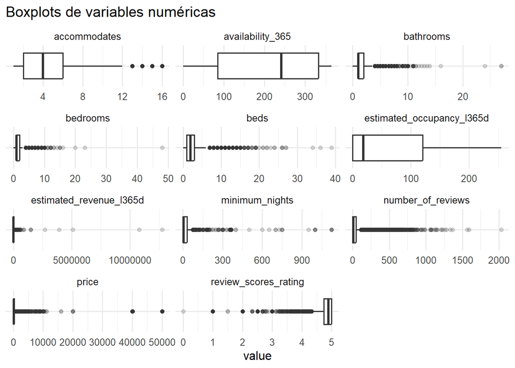

```r
plot_sample %>%
  pivot_longer(cols = everything(), names_to = "variable", values_to = "value") %>%
  ggplot(aes(x = variable, y = value)) +
  geom_boxplot(outlier.alpha = 0.2) +
  facet_wrap(~ variable, scales = "free", ncol = 3) +
  coord_flip() +
  theme(axis.title.y = element_blank(),
        axis.text.y = element_blank(),
        axis.ticks.y = element_blank()) +
  labs(title = "Boxplots de variables numéricas")
```

El análisis univariado de las variables numéricas muestra que muchas de ellas presentan distribuciones claramente asimétricas y con presencia de valores extremos. Variables como number_of_reviews, host_listings_count, host_total_listings_count y varios conteos calculados de propiedades exhiben medianas bajas y máximos muy altos, lo que sugiere una fuerte concentración de observaciones en valores pequeños y una cola derecha larga. Esta situación es consistente con un mercado donde la mayoría de los anfitriones poseen pocas propiedades, mientras que un grupo reducido concentra una gran cantidad de anuncios.

## Categóricas

```r
cat_vars <- listings_clean %>%
  select(where(~ is.character(.x) || is.factor(.x))) %>%
  names()

categorical_summary <- map_dfr(cat_vars, function(v) {
  x <- listings_clean[[v]]
  tb <- sort(table(x, useNA = "ifany"), decreasing = TRUE)

  tibble(
    variable = v,
    n_levels = n_distinct(x, na.rm = TRUE),
    top_1 = names(tb)[1],
    freq_top_1 = as.integer(tb[1]),
    pct_top_1 = as.numeric(tb[1]) / sum(tb),
    rare_levels_lt_1pct = sum(prop.table(tb) < 0.01, na.rm = TRUE)
  )
}) %>%
  arrange(desc(n_levels))

categorical_summary
```

```
## # A tibble: 18 × 6
##    variable              n_levels top_1 freq_top_1 pct_top_1 rare_levels_lt_1pct
##    <chr>                    <int> <chr>      <int>     <dbl>               <int>
##  1 license                  52058 ""         81150    0.477                52056
##  2 host_name                22307 "Blu…       2410    0.0142               22306
##  3 host_location             2871 ""         38866    0.228                 2859
##  4 host_neighbourhood        2832 ""         29976    0.176                 2823
##  5 neighbourhood_cleans…      855 "Pri…       6610    0.0389                 843
##  6 property_type              119 "Ent…      50711    0.298                  109
##  7 neighbourhood_group_…       17  <NA>      50279    0.296                    5
##  8 city                        10 "Los…      45362    0.267                    0
##  9 host_verifications           8 "['e…     133710    0.786                    5
## 10 host_response_time           6 "wit…     106112    0.624                    1
## 11 room_type                    4 "Ent…     126749    0.745                    2
## 12 host_is_superhost            3 "f"       100362    0.590                    0
## 13 host_has_profile_pic         3 "t"       165792    0.975                    1
## 14 host_identity_verifi…        3 "t"       157020    0.923                    1
## 15 neighbourhood                3 ""         86259    0.507                    1
## 16 has_availability             3 "t"       159670    0.939                    1
## 17 source                       2 "cit…     139106    0.818                    0
## 18 instant_bookable             2 "No"      112815    0.663                    0
```

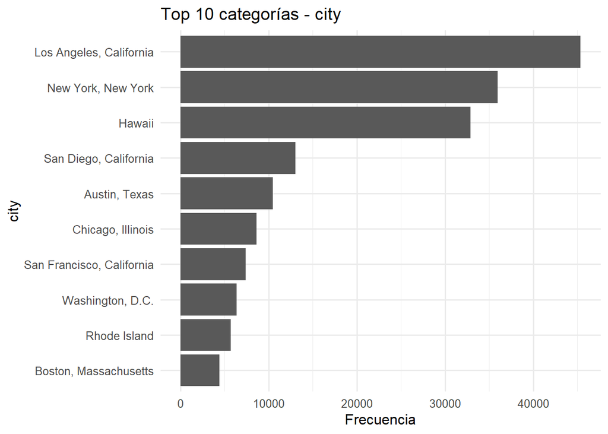

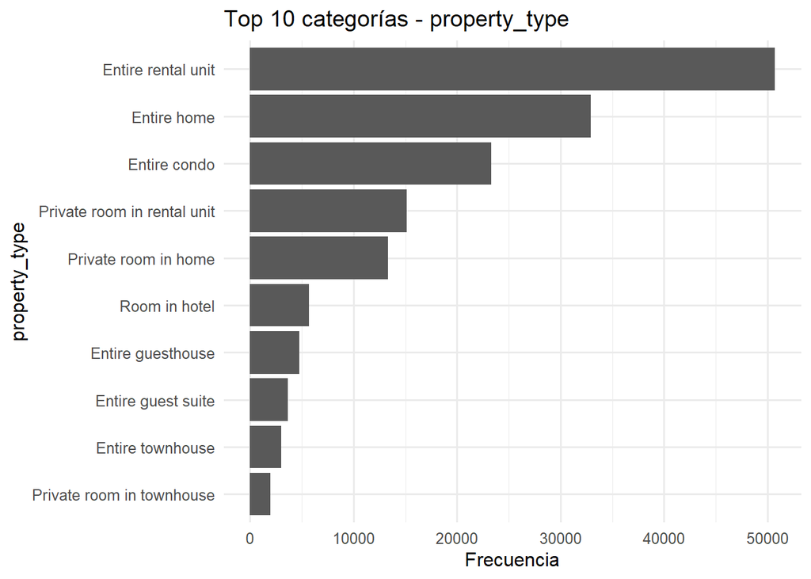

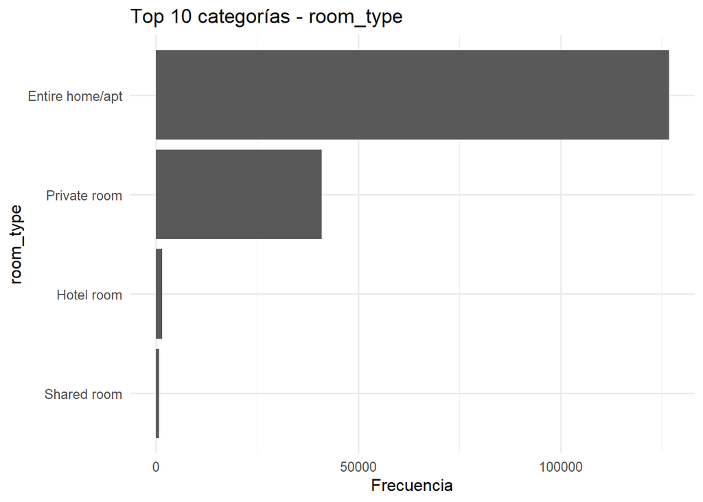

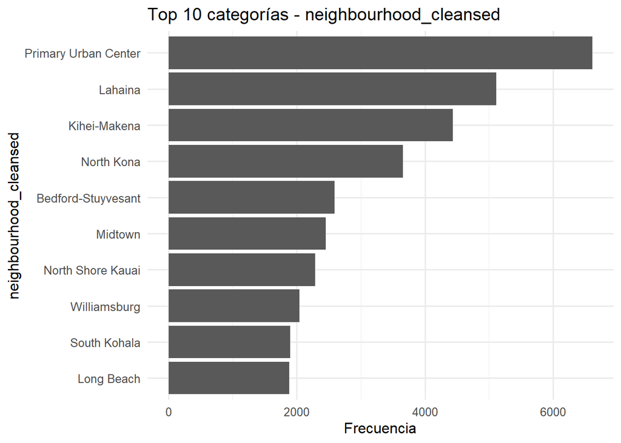

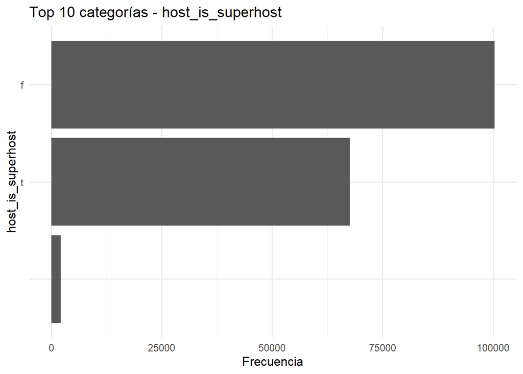

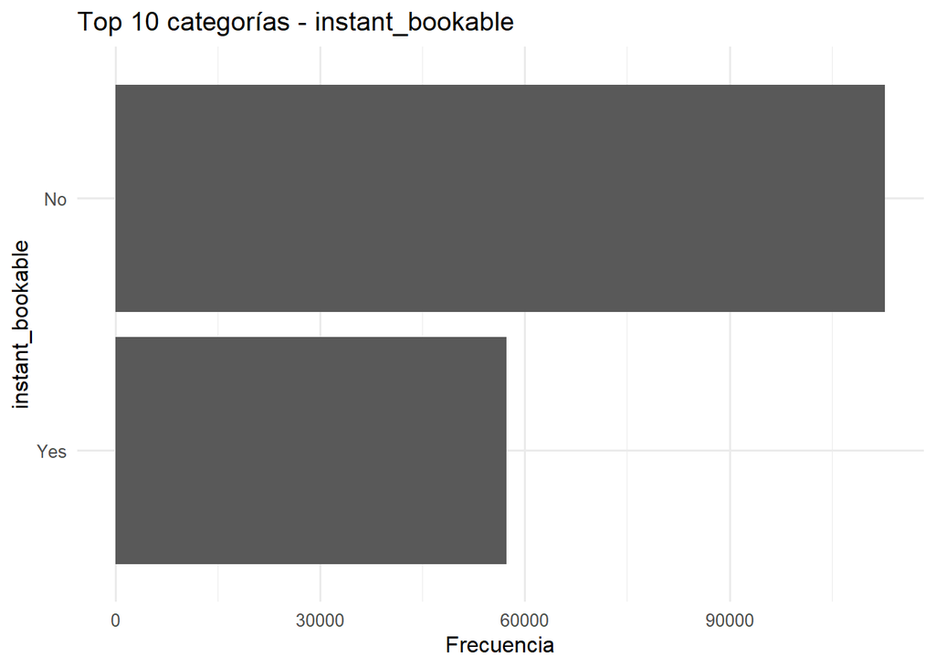

```r
plot_top_bars <- function(var, top_n = 10) {
  tmp <- listings_clean %>%
    filter(!is.na(.data[[var]])) %>%
    count(.data[[var]], sort = TRUE) %>%
    slice_head(n = top_n)

  ggplot(tmp, aes(x = reorder(as.character(.data[[var]]), n), y = n)) +
    geom_col() +
    coord_flip() +
    labs(
      title = paste("Top", top_n, "categorías -", var),
      x = var, y = "Frecuencia"
    )
}

key_cat <- intersect(
  c("city", "property_type", "room_type", "neighbourhood_cleansed",
    "host_is_superhost", "instant_bookable"),
  names(listings_clean)
)

walk(key_cat, ~ print(plot_top_bars(.x, top_n = 10)))
```

Las variables categóricas presentan distintos niveles de complejidad. Algunas son compactas y fáciles de interpretar, como room_type, instant_bookable o host_is_superhost, mientras que otras tienen cardinalidad extremadamente alta, como license, host_name, host_location, host_neighbourhood y neighbourhood_cleansed. Por ejemplo, license tiene más de 52 mil niveles, y host_name supera los 22 mil, lo que indica que estas variables no son convenientes para incorporarlas directamente en un modelo lineal sin un tratamiento adicional.

Entre las categorías dominantes, se observa que room_type está fuertemente concentrada en “Entire home/apt”, que representa alrededor del 74.5% de los registros. Asimismo, instant_bookable muestra predominio de la categoría “No”, y en host_is_superhost predominan los anfitriones que no son superhost. En la variable city aparecen 10 categorías, siendo las más frecuentes Los Angeles, New York y Hawaii, mientras que en property_type predominan tipos como Entire rental unit, Entire home y Entire condo. Estos resultados sugieren que la muestra está compuesta principalmente por propiedades completas y por mercados urbanos o turísticos de alta demanda.

# Análisis de la variable respuesta: price

```r
price_summary <- summarise_numeric(listings_clean, "price")
price_summary
```

```
## # A tibble: 1 × 13
##   variable     n  mean median    sd   min   p01   p25   p75   p99   max  skew
##   <chr>    <int> <dbl>  <dbl> <dbl> <dbl> <dbl> <dbl> <dbl> <dbl> <dbl> <dbl>
## 1 price    75426  691.    191 3989.     8    35   119   323  8853 50123  10.6
## # ℹ 1 more variable: outliers_iqr <int>
```

```r
tibble(
  variable = c("price", "log_price"),
  skew = c(
    safe_skew(listings_clean$price),
    safe_skew(listings_clean$log_price)
  )
)
```

```
## # A tibble: 2 × 2
##   variable   skew
##   <chr>     <dbl>
## 1 price     10.6
## 2 log_price  1.74
```

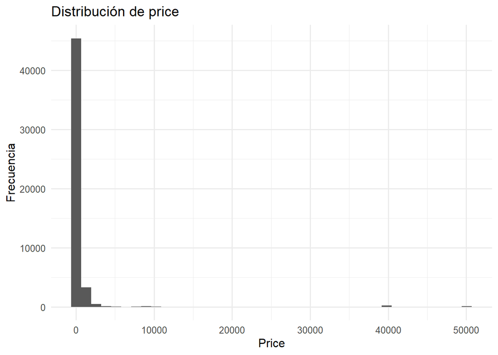

```r
listings_clean %>%
  filter(!is.na(price)) %>%
  slice_sample(n = min(50000, nrow(.))) %>%
  ggplot(aes(x = price)) +
  geom_histogram(bins = 40) +
  labs(title = "Distribución de price", x = "Price", y = "Frecuencia")
```

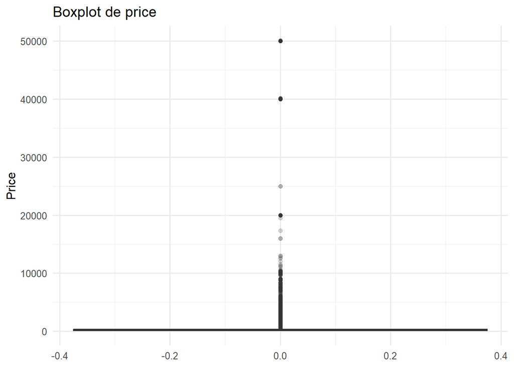

```r
listings_clean %>%
  filter(!is.na(price)) %>%
  ggplot(aes(y = price)) +
  geom_boxplot(outlier.alpha = 0.2) +
  labs(title = "Boxplot de price", y = "Price")
```

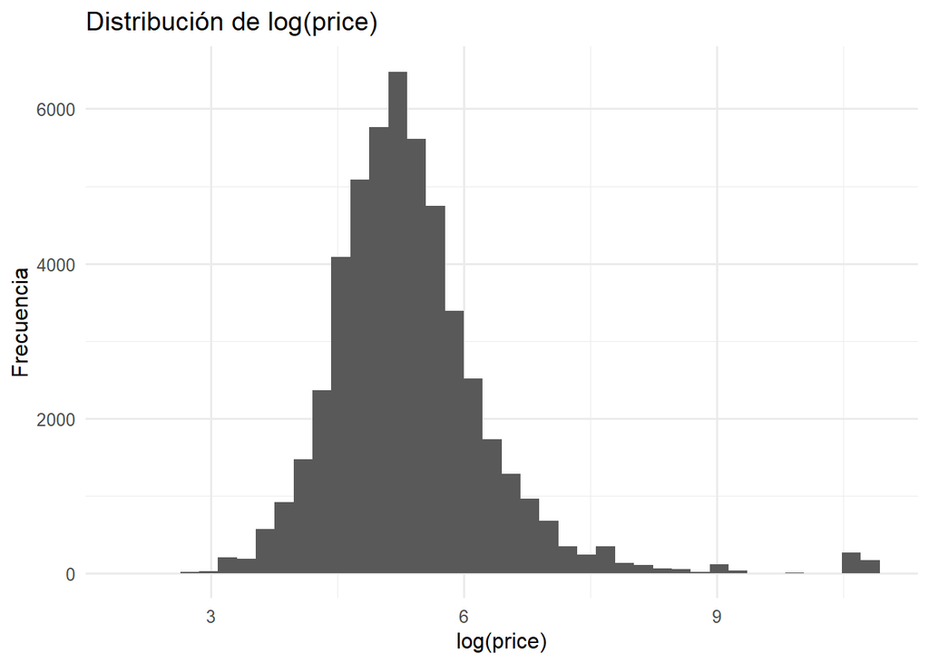

```r
listings_clean %>%
  filter(!is.na(log_price)) %>%
  slice_sample(n = min(50000, nrow(.))) %>%
  ggplot(aes(x = log_price)) +
  geom_histogram(bins = 40) +
  labs(title = "Distribución de log(price)", x = "log(price)", y = "Frecuencia")
```

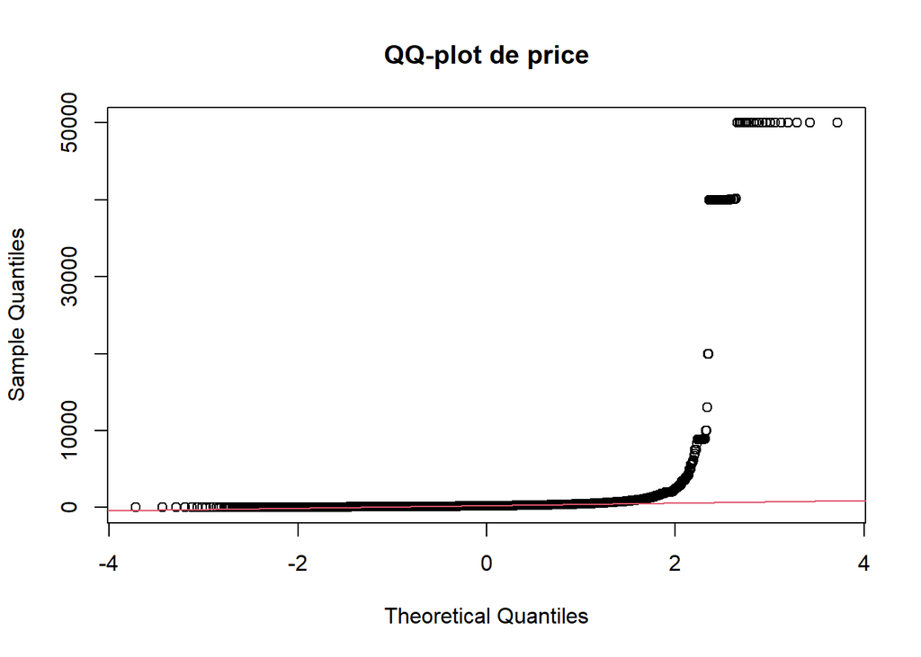

```r
price_sample <- listings_clean %>%
  filter(!is.na(price)) %>%
  pull(price)

price_sample <- sample(price_sample, size = min(5000, length(price_sample)))

qqnorm(price_sample, main = "QQ-plot de price")
qqline(price_sample, col = 2)
```

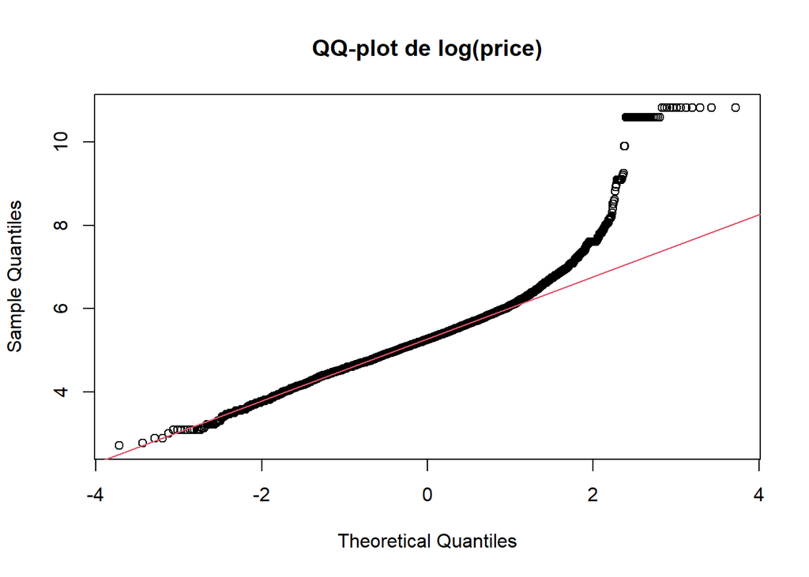

```r
logprice_sample <- listings_clean %>%
  filter(!is.na(log_price)) %>%
  pull(log_price)

logprice_sample <- sample(logprice_sample, size = min(5000, length(logprice_sample)))

qqnorm(logprice_sample, main = "QQ-plot de log(price)")
qqline(logprice_sample, col = 2)
```

La variable objetivo price presenta una distribución fuertemente asimétrica a la derecha. Sobre las observaciones con precio disponible (75,426 registros), la media es 691, mientras que la mediana es 191, lo que revela una marcada influencia de valores extremos altos. Además, el precio mínimo observado es 8, el percentil 99 es 8,853 y el máximo alcanza 50,123, confirmando la existencia de alojamientos extraordinariamente caros en comparación con el grueso de la muestra. El coeficiente de asimetría de price es 10.6, lo que indica una distribución muy alejada de la normalidad.

Las gráficas del histograma, boxplot y QQ-plot refuerzan esta conclusión: la mayor parte de las propiedades se concentra en rangos bajos o medios de precio, mientras que un grupo reducido de observaciones extremadamente caras alarga la cola derecha de la distribución. Al aplicar la transformación log(price), la asimetría disminuye de 10.6 a 1.74, y la forma de la distribución mejora de manera considerable, acercándose mucho más a una forma aproximadamente simétrica. Por ello, desde el punto de vista exploratorio y de modelado, existe evidencia suficiente para considerar log(price) como una mejor alternativa para ajustar un modelo de regresión.

# Relación de cada variable con el precio

## Numéricas vs precio

```r
candidate_num <- intersect(
  c("accommodates", "bathrooms", "bedrooms", "beds",
    "minimum_nights", "maximum_nights",
    "number_of_reviews", "number_of_reviews_ltm", "number_of_reviews_l30d",
    "review_scores_rating", "review_scores_cleanliness",
    "review_scores_location", "reviews_per_month",
    "availability_30", "availability_60", "availability_90", "availability_365",
    "estimated_occupancy_l365d", "estimated_revenue_l365d"),
  names(listings_clean)
)

cor_price <- map_dfr(candidate_num, function(v) {
  tmp <- listings_clean %>%
    select(price, all_of(v)) %>%
    drop_na()

  tibble(
    variable = v,
    pearson = cor(tmp$price, tmp[[v]], method = "pearson"),
    spearman = cor(tmp$price, tmp[[v]], method = "spearman")
  )
}) %>%
  arrange(desc(abs(spearman)))

cor_price
```

```
## # A tibble: 19 × 3
##    variable                   pearson spearman
##    <chr>                        <dbl>    <dbl>
##  1 accommodates               0.0986   0.596
##  2 bathrooms                  0.0818   0.522
##  3 beds                      -0.0133   0.514
##  4 bedrooms                   0.0545   0.508
##  5 review_scores_location     0.0176   0.291
##  6 estimated_occupancy_l365d -0.103   -0.250
##  7 reviews_per_month         -0.0597  -0.207
##  8 number_of_reviews         -0.0674  -0.197
##  9 number_of_reviews_ltm     -0.0765  -0.195
## 10 review_scores_rating      -0.0185   0.179
## 11 review_scores_cleanliness  0.00777  0.163
## 12 number_of_reviews_l30d    -0.0624  -0.158
## 13 maximum_nights             0.108    0.0900
## 14 estimated_revenue_l365d    0.222    0.0709
## 15 availability_90           -0.0283  -0.0592
## 16 minimum_nights            -0.0424  -0.0526
## 17 availability_30           -0.0173   0.0241
## 18 availability_60           -0.0226  -0.0239
## 19 availability_365          -0.0265  -0.00841
```

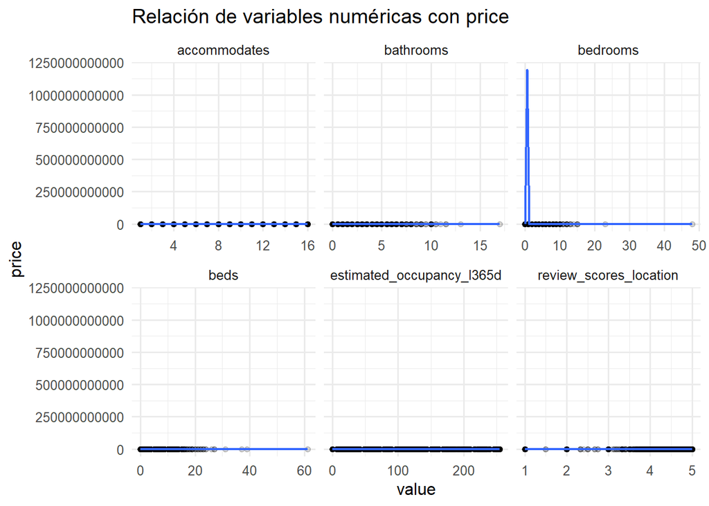

```r
top_num_price <- cor_price %>%
  slice_max(order_by = abs(spearman), n = min(6, nrow(cor_price)), with_ties = FALSE) %>%
  pull(variable)

num_price_sample <- listings_clean %>%
  select(price, all_of(top_num_price)) %>%
  drop_na() %>%
  slice_sample(n = min(30000, nrow(.)))

num_price_sample %>%
  pivot_longer(cols = -price, names_to = "variable", values_to = "value") %>%
  ggplot(aes(x = value, y = price)) +
  geom_point(alpha = 0.15) +
  geom_smooth(method = "loess", se = FALSE, linewidth = 0.8) +
  facet_wrap(~ variable, scales = "free_x", ncol = 3) +
  labs(title = "Relación de variables numéricas con price")
```

El análisis de correlación entre variables numéricas y price muestra que las asociaciones más claras aparecen en variables vinculadas al tamaño y capacidad del alojamiento. En particular, las mayores correlaciones de Spearman corresponden a accommodates (0.596), bathrooms (0.522), beds (0.514) y bedrooms (0.508). Esto sugiere que, en términos generales, a mayor capacidad del alojamiento y mayor número de habitaciones o baños, mayor tiende a ser el precio. Estas variables aparecen como candidatas naturales para el modelo predictivo, tanto por su interpretación de negocio como por su asociación empírica con la variable respuesta.

Por otro lado, variables relacionadas con reseñas y actividad reciente presentan asociaciones débiles o moderadas, e incluso negativas, como ocurre con reviews_per_month, number_of_reviews, number_of_reviews_ltm y estimated_occupancy_l365d. Una posible interpretación es que los alojamientos más caros no necesariamente son los más frecuentes o los más demandados dentro de la plataforma. Asimismo, el hecho de que varias correlaciones de Pearson sean bastante menores que las de Spearman sugiere que la relación entre precio y estas variables no es estrictamente lineal y está influida por la asimetría y los outliers del precio.

También conviene notar que estimated_revenue_l365d muestra una relación positiva con price, pero esta variable debe manejarse con mucho cuidado en el modelado, ya que conceptualmente puede incorporar información muy cercana a la variable objetivo. En consecuencia, aunque su exploración es útil para entender el negocio, no sería recomendable mantenerla como predictor sin antes evaluar riesgo de fuga de información.

## Categóricas vs precio

```r
candidate_cat <- intersect(
  c("city", "property_type", "room_type", "neighbourhood_cleansed",
    "host_is_superhost", "instant_bookable"),
  names(listings_clean)
)

cat_price_summary <- map_dfr(candidate_cat, function(v) {
  listings_clean %>%
    filter(!is.na(price), !is.na(.data[[v]])) %>%
    group_by(grupo = as.character(.data[[v]])) %>%
    summarise(
      n = n(),
      mean_price = mean(price),
      median_price = median(price),
      .groups = "drop"
    ) %>%
    arrange(desc(n)) %>%
    slice_head(n = 10) %>%
    mutate(variable = v) %>%
    relocate(variable)
})

cat_price_summary
```

```
## # A tibble: 36 × 5
##    variable      grupo                     n mean_price median_price
##    <chr>         <chr>                 <int>      <dbl>        <dbl>
##  1 city          Hawaii                32540       865.          230
##  2 city          San Diego, California 11290       600.          176
##  3 city          Austin, Texas         10455       358.          134
##  4 city          Chicago, Illinois      7809       586.          153
##  5 city          Rhode Island           4946       852.          275
##  6 city          Washington, D.C.       4885       440.          124
##  7 city          Boston, Massachusetts  3501       722.          206
##  8 property_type Entire rental unit    20342       287.          168
##  9 property_type Entire condo          19066       409.          216
## 10 property_type Entire home           16272       453.          281
## # ℹ 26 more rows
```

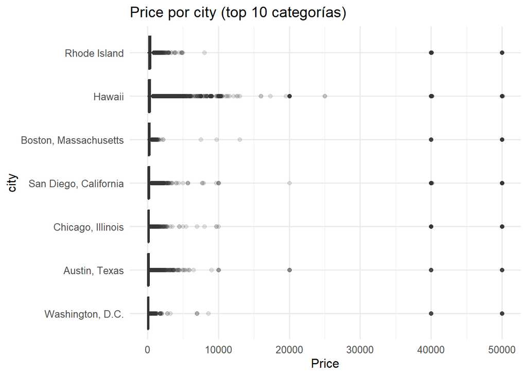

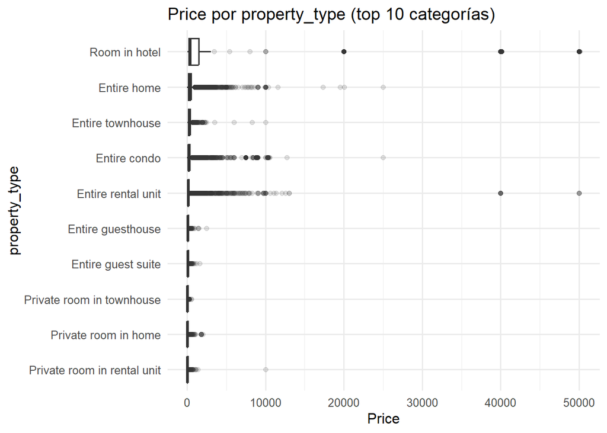

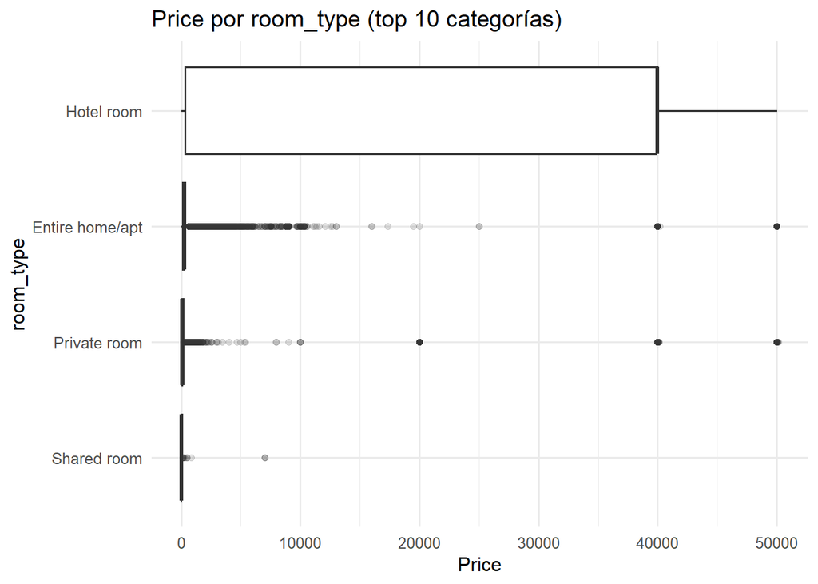

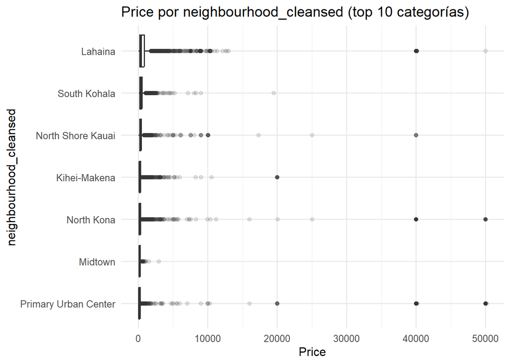

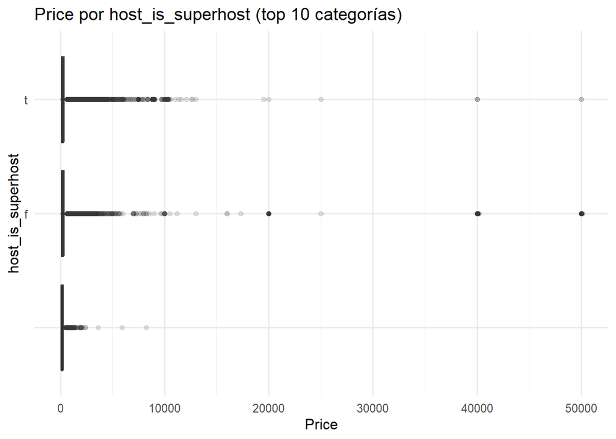

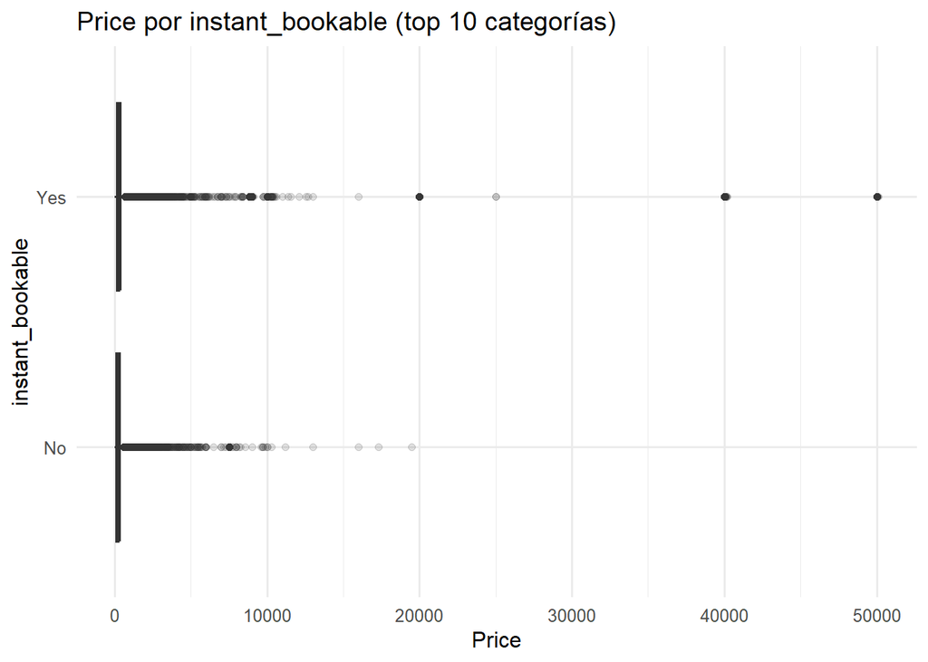

```r
plot_box_cat_price <- function(var, top_n = 10) {
  top_levels <- listings_clean %>%
    filter(!is.na(.data[[var]])) %>%
    count(.data[[var]], sort = TRUE) %>%
    slice_head(n = top_n) %>%
    pull(1) %>%
    as.character()

  tmp <- listings_clean %>%
    filter(as.character(.data[[var]]) %in% top_levels, !is.na(price))

  ggplot(tmp, aes(x = forcats::fct_reorder(as.factor(.data[[var]]), price, .fun = median), y = price)) +
    geom_boxplot(outlier.alpha = 0.15) +
    coord_flip() +
    labs(
      title = paste("Price por", var, "(top", top_n, "categorías)"),
      x = var, y = "Price"
    )
}

walk(candidate_cat, ~ print(plot_box_cat_price(.x, top_n = 10)))
```

Las variables categóricas también muestran diferencias relevantes en los niveles de precio. En city, por ejemplo, se observan medianas y medias distintas entre mercados: Hawaii y Rhode Island presentan precios más altos que Austin, Texas o Washington, D.C., lo que sugiere un efecto importante de la localización geográfica sobre la variable respuesta. Este resultado es coherente con la idea de que el precio no depende únicamente de las características físicas del alojamiento, sino también del mercado local en el que compite.

En property_type, los alojamientos completos como Entire home y Entire condo muestran valores medianos superiores a los tipos compartidos o privados. De manera similar, en room_type se aprecia que Entire home/apt tiende a ubicarse por encima de Private room y Shared room, lo que confirma que el nivel de privacidad y uso exclusivo del espacio influye de manera importante en el precio. Estas diferencias hacen pensar que variables categóricas como city, property_type y room_type serán determinantes en el modelo final.

En cambio, para variables binarias como host_is_superhost e instant_bookable, las diferencias visuales parecen menos marcadas que en ubicación o tipo de propiedad. Aun así, pueden seguir siendo útiles como variables explicativas complementarias, especialmente si interactúan con otros atributos del anuncio. En conjunto, el análisis categórico muestra que existen segmentos de mercado con comportamientos de precio claramente diferenciados.

# Correlación y multicolinealidad

```r
corr_vars <- intersect(
  c("accommodates", "bathrooms", "bedrooms", "beds",
    "minimum_nights", "maximum_nights",
    "availability_30", "availability_60", "availability_90", "availability_365",
    "number_of_reviews", "number_of_reviews_ltm", "reviews_per_month",
    "review_scores_rating", "estimated_occupancy_l365d"),
  names(listings_clean)
)

corr_df <- listings_clean %>%
  select(all_of(corr_vars)) %>%
  select(where(is.numeric))

corr_mat <- cor(corr_df, use = "pairwise.complete.obs")

corr_mat
```

```
##                           accommodates    bathrooms     bedrooms          beds
## accommodates               1.000000000  0.657814443  0.781775374  0.8136172856
## bathrooms                  0.657814443  1.000000000  0.717667648  0.6201359747
## bedrooms                   0.781775374  0.717667648  1.000000000  0.7640440873
## beds                       0.813617286  0.620135975  0.764044087  1.0000000000
## minimum_nights            -0.148867028 -0.042861686 -0.043154322 -0.1177591470
## maximum_nights            -0.002657571 -0.001263189 -0.002044617 -0.0006178945
## availability_30            0.065224631  0.070069993  0.018753803 -0.0131886241
## availability_60            0.073523800  0.066714467  0.014326873 -0.0211743377
## availability_90            0.076220992  0.062822289  0.009463669 -0.0264407077
## availability_365           0.112347808  0.097100130  0.031291567  0.0127362965
## number_of_reviews         -0.021700638 -0.080037108 -0.082426357 -0.0269414624
## number_of_reviews_ltm      0.049118168 -0.040082178 -0.033736609  0.0142270971
## reviews_per_month          0.046924397 -0.053356644 -0.037522951 -0.0056650346
## review_scores_rating       0.054049280  0.046244412  0.060852313  0.0593245671
## estimated_occupancy_l365d  0.016564686 -0.067161598 -0.061343082 -0.0162583749
##                           minimum_nights maximum_nights availability_30
## accommodates                -0.148867028  -0.0026575710     0.065224631
## bathrooms                   -0.042861686  -0.0012631894     0.070069993
## bedrooms                    -0.043154322  -0.0020446166     0.018753803
## beds                        -0.117759147  -0.0006178945    -0.013188624
## minimum_nights               1.000000000   0.0010571746    -0.005435574
## maximum_nights               0.001057175   1.0000000000    -0.002803346
## availability_30             -0.005435574  -0.0028033460     1.000000000
## availability_60             -0.030835715  -0.0033261009     0.925814556
## availability_90             -0.043231771  -0.0036193025     0.857481364
## availability_365            -0.026002961  -0.0038407273     0.528602897
## number_of_reviews           -0.147442201  -0.0011175794    -0.029504553
## number_of_reviews_ltm       -0.220631354  -0.0012078784    -0.017955556
## reviews_per_month           -0.233285060  -0.0020545479     0.032371134
## review_scores_rating        -0.032368054  -0.0077760869    -0.081904473
## estimated_occupancy_l365d   -0.143078784  -0.0018686999    -0.059153862
##                           availability_60 availability_90 availability_365
## accommodates                  0.073523800     0.076220992      0.112347808
## bathrooms                     0.066714467     0.062822289      0.097100130
## bedrooms                      0.014326873     0.009463669      0.031291567
## beds                         -0.021174338    -0.026440708      0.012736297
## minimum_nights               -0.030835715    -0.043231771     -0.026002961
## maximum_nights               -0.003326101    -0.003619302     -0.003840727
## availability_30               0.925814556     0.857481364      0.528602897
```

[output cut: 41 more lines]

```
## accommodates                             0.01656469
## bathrooms                               -0.06716160
## bedrooms                                -0.06134308
## beds                                    -0.01625837
## minimum_nights                          -0.14307878
## maximum_nights                          -0.00186870
## availability_30                         -0.05915386
## availability_60                          0.02295303
## availability_90                          0.06898241
## availability_365                         0.09113551
## number_of_reviews                        0.52079450
## number_of_reviews_ltm                    0.69609211
## reviews_per_month                        0.59133717
## review_scores_rating                     0.12489261
## estimated_occupancy_l365d                1.00000000
```

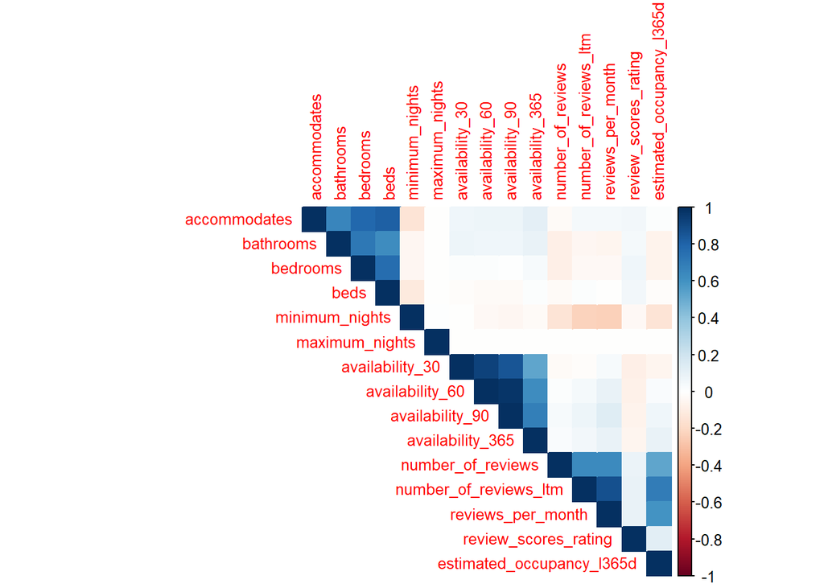

```r
corrplot::corrplot(
  corr_mat,
  method = "color",
  type = "upper",
  tl.cex = 0.8,
  number.cex = 0.7
)
```

```r
high_corr_pairs <- as.data.frame(as.table(corr_mat)) %>%
  filter(Var1 != Var2) %>%
  mutate(abs_cor = abs(Freq)) %>%
  arrange(desc(abs_cor)) %>%
  filter(abs_cor >= 0.70) %>%
  distinct(
    par = map2_chr(Var1, Var2, ~ paste(sort(c(.x, .y)), collapse = " - ")),
    .keep_all = TRUE
  ) %>%
  select(Var1, Var2, correlacion = Freq, abs_cor)

high_corr_pairs
```

```
##                Var1                  Var2 correlacion   abs_cor
## 1   availability_90       availability_60   0.9714017 0.9714017
## 2   availability_60       availability_30   0.9258146 0.9258146
## 3 reviews_per_month number_of_reviews_ltm   0.8724448 0.8724448
## 4   availability_90       availability_30   0.8574814 0.8574814
## 5              beds          accommodates   0.8136173 0.8136173
## 6          bedrooms          accommodates   0.7817754 0.7817754
## 7              beds              bedrooms   0.7640441 0.7640441
## 8          bedrooms             bathrooms   0.7176676 0.7176676
```

```r
high_corr_pairs <- as.data.frame(as.table(corr_mat)) %>%
  filter(Var1 != Var2) %>%
  mutate(abs_cor = abs(Freq)) %>%
  arrange(desc(abs_cor)) %>%
  filter(abs_cor >= 0.70) %>%
  distinct(
    par = map2_chr(Var1, Var2, ~ paste(sort(c(.x, .y)), collapse = " - ")),
    .keep_all = TRUE
  ) %>%
  select(Var1, Var2, correlacion = Freq, abs_cor)

high_corr_pairs
```

```
##                Var1                  Var2 correlacion   abs_cor
## 1   availability_90       availability_60   0.9714017 0.9714017
## 2   availability_60       availability_30   0.9258146 0.9258146
## 3 reviews_per_month number_of_reviews_ltm   0.8724448 0.8724448
## 4   availability_90       availability_30   0.8574814 0.8574814
## 5              beds          accommodates   0.8136173 0.8136173
## 6          bedrooms          accommodates   0.7817754 0.7817754
## 7              beds              bedrooms   0.7640441 0.7640441
## 8          bedrooms             bathrooms   0.7176676 0.7176676
```

```r
vif_vars <- intersect(
  c("accommodates", "bathrooms", "bedrooms", "beds",
    "minimum_nights", "number_of_reviews",
    "review_scores_rating", "availability_365"),
  names(listings_clean)
)

if (length(vif_vars) >= 2) {
  vif_df <- listings_clean %>%
    select(price, all_of(vif_vars)) %>%
    drop_na()

  if (nrow(vif_df) > 10000) {
    vif_df <- vif_df %>% slice_sample(n = 10000)
  }

  fit_vif <- lm(price ~ ., data = vif_df)

  vif_tbl <- tibble(
    variable = names(car::vif(fit_vif)),
    vif = as.numeric(car::vif(fit_vif))
  ) %>%
    arrange(desc(vif))

  vif_tbl
}
```

```
## # A tibble: 8 × 2
##   variable               vif
##   <chr>                <dbl>
## 1 accommodates          5.26
## 2 bedrooms              4.60
## 3 beds                  4.37
## 4 bathrooms             2.47
## 5 number_of_reviews     1.05
## 6 minimum_nights        1.05
## 7 review_scores_rating  1.03
## 8 availability_365      1.02
```

La matriz de correlación entre variables numéricas revela bloques claros de variables redundantes. El primer bloque aparece en las variables de disponibilidad: availability_90 y availability_60 presentan una correlación de 0.971, mientras que availability_60 y availability_30 alcanzan 0.926. Esto indica que estas variables contienen información muy similar y, en un modelo predictivo, probablemente no sea necesario incluirlas simultáneamente. Un segundo bloque importante aparece en las variables de tamaño del alojamiento: beds y accommodates tienen correlación de 0.814, bedrooms y accommodates de 0.782, y beds y bedrooms de 0.764. Estas relaciones sugieren redundancia parcial entre características que describen la capacidad del alojamiento.

También se observa una alta relación entre métricas de actividad o reseñas, particularmente entre reviews_per_month y number_of_reviews_ltm con una correlación de 0.872. En general, estos resultados muestran que varias variables capturan dimensiones similares del fenómeno, por lo que será importante seleccionar una representación parsimoniosa al construir el modelo. Desde el punto de vista del EDA, este hallazgo es útil porque permite justificar por qué algunas variables podrían excluirse o resumirse en etapas posteriores.

# Análisis de grupos (clustering / segmentación)

```r
cluster_vars <- intersect(
  c("accommodates",
    "bathrooms",
    "minimum_nights",
    "number_of_reviews",
    "review_scores_rating",
    "availability_365"),
  names(listings_clean)
)

cluster_vars
```

```
## [1] "accommodates"         "bathrooms"            "minimum_nights"
## [4] "number_of_reviews"    "review_scores_rating" "availability_365"
```

```r
mode_stat <- function(x) {
  x <- na.omit(x)
  if (length(x) == 0) return(NA_character_)
  names(sort(table(x), decreasing = TRUE))[1]
}

impute_median <- function(x) {
  if (!is.numeric(x)) return(x)
  x[is.na(x)] <- median(x, na.rm = TRUE)
  x
}

cluster_base <- listings_clean %>%
  select(any_of(c(cluster_vars, "price", "room_type", "property_type", "city")))

cluster_num <- cluster_base %>%
  select(all_of(cluster_vars)) %>%
  mutate(across(everything(), impute_median))

# Eliminar variables con varianza 0 si las hubiera
zero_var_cols <- names(cluster_num)[sapply(cluster_num, function(x) sd(x, na.rm = TRUE) == 0)]
cluster_num <- cluster_num %>% select(-any_of(zero_var_cols))

cluster_vars_final <- names(cluster_num)

# Escalamiento
cluster_scaled_all <- scale(cluster_num)

# Muestra para que kmeans no sea tan pesado
set.seed(123)
sample_n_clust <- min(30000, nrow(cluster_scaled_all))
sample_idx <- sample(seq_len(nrow(cluster_scaled_all)), sample_n_clust)

cluster_scaled_sample <- cluster_scaled_all[sample_idx, , drop = FALSE]
cluster_sample_df <- cluster_base[sample_idx, ]

dim(cluster_scaled_sample)
```

```
## [1] 30000     6
```

```r
set.seed(123)

# Submuestra para elbow
n_elbow <- min(5000, nrow(cluster_scaled_all))
idx_elbow <- sample(seq_len(nrow(cluster_scaled_all)), n_elbow)
cluster_scaled_elbow <- cluster_scaled_all[idx_elbow, , drop = FALSE]

# Submuestra más pequeña para silhouette
n_sil <- min(2500, nrow(cluster_scaled_all))
idx_sil <- sample(seq_len(nrow(cluster_scaled_all)), n_sil)
cluster_scaled_sil <- cluster_scaled_all[idx_sil, , drop = FALSE]

dim(cluster_scaled_elbow)
```

```
## [1] 5000    6
```

```r
dim(cluster_scaled_sil)
```

```
## [1] 2500    6
```

```r
k_grid <- 2:8

wss_tbl <- tibble(
  k = k_grid,
  wss = map_dbl(k_grid, function(k) {
    set.seed(123)
    kmeans(cluster_scaled_elbow, centers = k, nstart = 10, iter.max = 50)$tot.withinss
  })
)

wss_tbl
```

```
## # A tibble: 7 × 2
##       k    wss
##   <int>  <dbl>
## 1     2 27310.
## 2     3 23838.
## 3     4 20612.
## 4     5 17520.
## 5     6 16071.
## 6     7 13345.
## 7     8 12204.
```

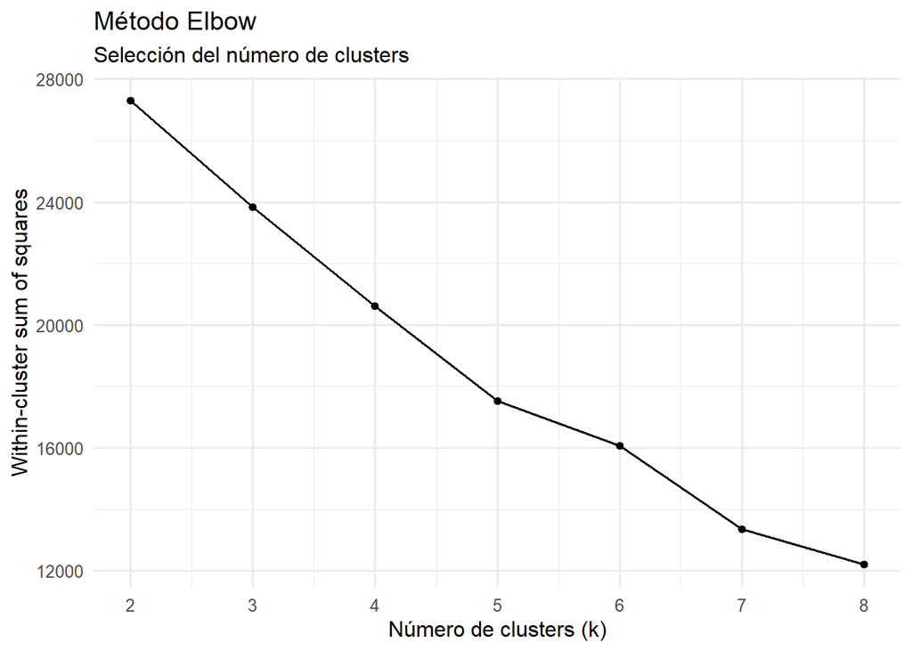

```r
ggplot(wss_tbl, aes(x = k, y = wss)) +
  geom_line() +
  geom_point() +
  scale_x_continuous(breaks = k_grid) +
  labs(
    title = "Método Elbow",
    subtitle = "Selección del número de clusters",
    x = "Número de clusters (k)",
    y = "Within-cluster sum of squares"
  )
```

```r
library(cluster)

k_grid <- 2:6

sil_tbl <- map_dfr(k_grid, function(k) {
  set.seed(123)
  km_tmp <- kmeans(cluster_scaled_sil, centers = k, nstart = 10, iter.max = 50)

  sil <- silhouette(km_tmp$cluster, dist(cluster_scaled_sil))

  tibble(
    k = k,
    avg_silhouette = mean(sil[, "sil_width"])
  )
})

sil_tbl
```

```
## # A tibble: 5 × 2
##       k avg_silhouette
##   <int>          <dbl>
## 1     2          0.283
## 2     3          0.257
## 3     4          0.265
## 4     5          0.295
## 5     6          0.311
```

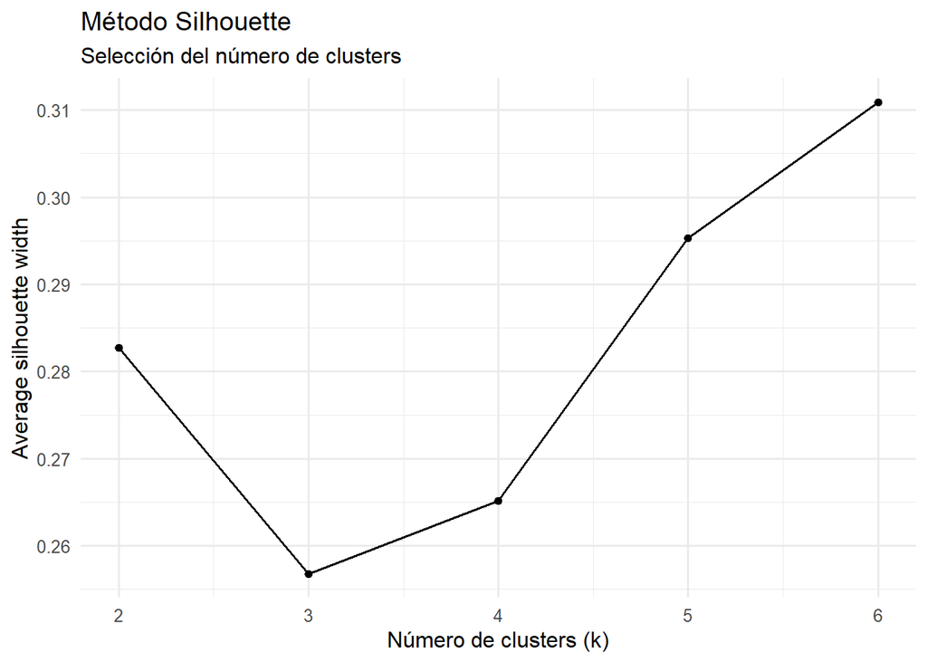

```r
ggplot(sil_tbl, aes(x = k, y = avg_silhouette)) +
  geom_line() +
  geom_point() +
  scale_x_continuous(breaks = k_grid) +
  labs(
    title = "Método Silhouette",
    subtitle = "Selección del número de clusters",
    x = "Número de clusters (k)",
    y = "Average silhouette width"
  )
```

```r
k_opt <- 6

set.seed(123)
km <- kmeans(cluster_scaled_sample, centers = k_opt, nstart = 25)

cluster_sample_df <- cluster_sample_df %>%
  mutate(cluster = factor(km$cluster))

table(cluster_sample_df$cluster)
```

```
##
##     1     2     3     4     5     6
## 13252  3969   247  1903 10177   452
```

```r
assign_to_centroids <- function(data_scaled, centers) {
  dist_mat <- sapply(seq_len(nrow(centers)), function(k) {
    rowSums((data_scaled - matrix(centers[k, ], nrow = nrow(data_scaled), ncol = ncol(data_scaled), byrow = TRUE))^2)
  })
  apply(dist_mat, 1, which.min)
}

cluster_all <- assign_to_centroids(cluster_scaled_all, km$centers)

listings_clustered <- cluster_base %>%
  mutate(cluster = factor(cluster_all))

glimpse(listings_clustered)
```

```
## Rows: 170,127
## Columns: 11
## $ accommodates         <int> 3, 2, 2, 3, 2, 1, 2, 6, 3, 2, 6, 4, 2, 3, 4, 6, 6…
## $ bathrooms            <dbl> 1.0, 1.0, 1.0, 2.0, 1.0, 1.0, 1.0, 1.0, 1.0, 1.0,…
## $ minimum_nights       <int> 2, 3, 4, 15, 30, 30, 7, 1, 2, 3, 14, 30, 2, 2, 2,…
## $ number_of_reviews    <int> 708, 339, 54, 19, 56, 9, 2, 1090, 188, 413, 45, 6…
## $ review_scores_rating <dbl> 4.85, 4.97, 4.57, 5.00, 4.95, 5.00, 5.00, 4.91, 4…
## $ availability_365     <int> 328, 316, 88, 321, 211, 258, 365, 335, 75, 63, 14…
## $ price                <dbl> 97, 160, 38, 145, 58, 49, 300, 150, 165, 117, 181…
## $ room_type            <fct> Entire home/apt, Entire home/apt, Entire home/apt…
## $ property_type        <fct> Entire guesthouse, Entire guesthouse, Entire gues…
## $ city                 <fct> "Austin, Texas", "Austin, Texas", "Austin, Texas"…
## $ cluster              <fct> 4, 4, 5, 1, 1, 1, 1, 4, 4, 4, 2, 5, 4, 4, 1, 2, 5…
```

```r
cluster_profile_numeric <- listings_clustered %>%
  group_by(cluster) %>%
  summarise(
    n = n(),
    across(
      any_of(c("price", cluster_vars_final)),
      list(
        media = ~ mean(.x, na.rm = TRUE),
        mediana = ~ median(.x, na.rm = TRUE)
      )
    ),
    .groups = "drop"
  )

cluster_profile_numeric
```

```
## # A tibble: 6 × 16
##   cluster     n price_media price_mediana accommodates_media
##   <fct>   <int>       <dbl>         <dbl>              <dbl>
## 1 1       74473        559.           175               3.39
## 2 2       23180       1372.           438               9.32
## 3 3        1339        271.           200               3.60
## 4 4       11044        165.           137               3.42
## 5 5       57558        615.           165               3.09
## 6 6        2533        965.           160               3.51
## # ℹ 11 more variables: accommodates_mediana <dbl>, bathrooms_media <dbl>,
## #   bathrooms_mediana <dbl>, minimum_nights_media <dbl>,
## #   minimum_nights_mediana <dbl>, number_of_reviews_media <dbl>,
## #   number_of_reviews_mediana <dbl>, review_scores_rating_media <dbl>,
## #   review_scores_rating_mediana <dbl>, availability_365_media <dbl>,
## #   availability_365_mediana <dbl>
```

```r
cluster_summary_short <- listings_clustered %>%
  group_by(cluster) %>%
  summarise(
    n = n(),
    precio_mediano = median(price, na.rm = TRUE),
    accommodates_mediano = median(accommodates, na.rm = TRUE),
    bathrooms_mediano = median(bathrooms, na.rm = TRUE),
    minimum_nights_mediano = median(minimum_nights, na.rm = TRUE),
    reviews_mediana = median(number_of_reviews, na.rm = TRUE),
    rating_mediano = median(review_scores_rating, na.rm = TRUE),
    availability_365_mediana = median(availability_365, na.rm = TRUE),
    .groups = "drop"
  )

cluster_summary_short
```

```
## # A tibble: 6 × 9
##   cluster     n precio_mediano accommodates_mediano bathrooms_mediano
##   <fct>   <int>          <dbl>                <dbl>             <dbl>
## 1 1       74473            175                    3                 1
## 2 2       23180            438                    8                 3
## 3 3        1339            200                    3                 1
## 4 4       11044            137                    3                 1
## 5 5       57558            165                    2                 1
## 6 6        2533            160                    2                 1
## # ℹ 4 more variables: minimum_nights_mediano <dbl>, reviews_mediana <dbl>,
## #   rating_mediano <dbl>, availability_365_mediana <dbl>
```

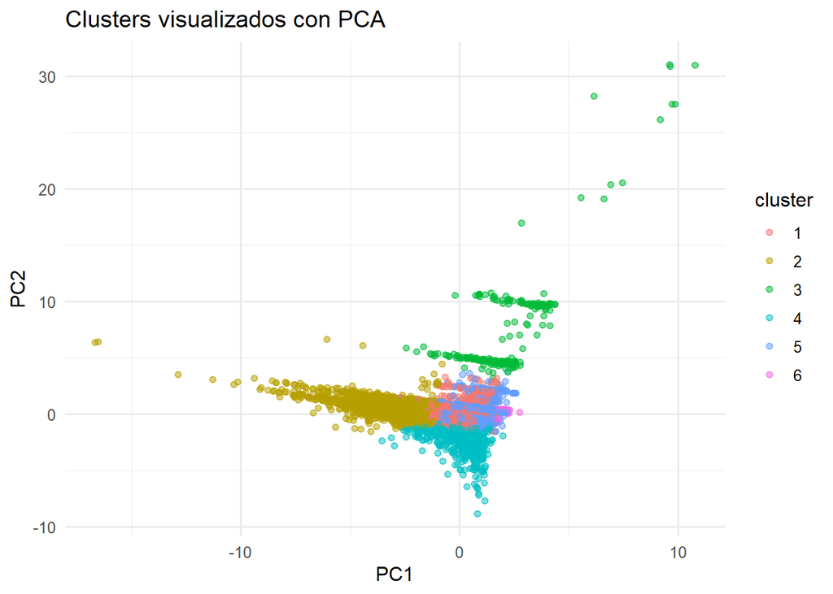

```r
pca <- prcomp(cluster_scaled_sample)

pca_df <- as_tibble(pca$x[, 1:2]) %>%
  mutate(cluster = cluster_sample_df$cluster)

ggplot(pca_df, aes(x = PC1, y = PC2, color = cluster)) +
  geom_point(alpha = 0.5) +
  labs(
    title = "Clusters visualizados con PCA",
    x = "PC1",
    y = "PC2"
  )
```

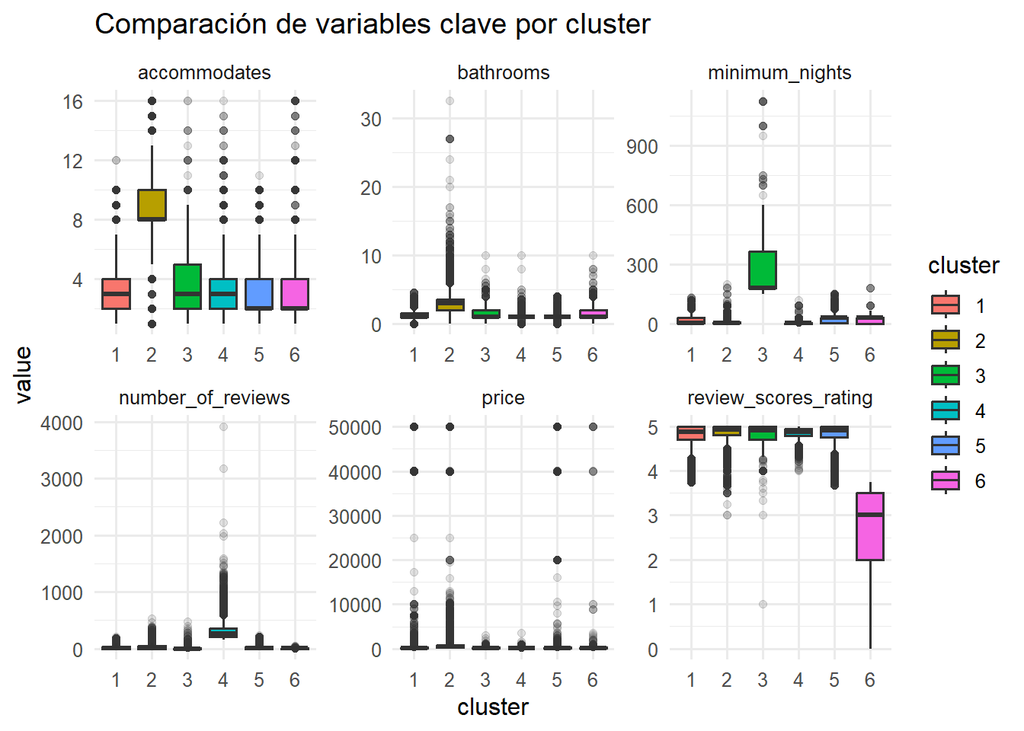

```r
vars_to_plot_cluster <- intersect(
  c("price", "accommodates", "bathrooms", "minimum_nights", "number_of_reviews", "review_scores_rating"),
  names(listings_clustered)
)

listings_clustered %>%
  select(cluster, all_of(vars_to_plot_cluster)) %>%
  pivot_longer(cols = -cluster, names_to = "variable", values_to = "value") %>%
  ggplot(aes(x = cluster, y = value, fill = cluster)) +
  geom_boxplot(outlier.alpha = 0.15) +
  facet_wrap(~ variable, scales = "free", ncol = 3) +
  labs(title = "Comparación de variables clave por cluster")
```

Para el análisis de segmentación se seleccionaron las variables accommodates, bathrooms, minimum_nights, number_of_reviews, review_scores_rating y availability_365, buscando representar tamaño del alojamiento, nivel de servicio, actividad y disponibilidad, pero evitando incorporar variables altamente redundantes. Esta decisión es consistente con el análisis de correlación previo, donde se observó una fuerte asociación entre variables como beds, bedrooms y accommodates, así como entre distintas medidas de disponibilidad, por lo que no resultaba conveniente incluirlas simultáneamente en el clustering. Posteriormente, se imputaron faltantes con la mediana, se estandarizaron las variables y se aplicó K-means. La elección de 6 clusters se apoyó en el método silhouette, cuyo valor promedio fue mayor para𝑘=6 que para las demás alternativas evaluadas.

La segmentación obtenida muestra que el mercado de propiedades no se divide únicamente en categorías simples como “económicas” o “premium”, sino en seis perfiles diferenciados. En la muestra usada para entrenar el algoritmo, los grupos tuvieron tamaños desiguales, lo que ya sugería una mezcla entre segmentos masivos y segmentos muy específicos. Una vez asignados los clusters al conjunto completo, se observó que los grupos 1 y 5 concentran la mayor parte de las propiedades, con 74,473 y 57,558 registros respectivamente, mientras que los clusters 3 y 6 son mucho más pequeños, con 1,339 y 2,533 observaciones. Esto sugiere que el mercado está dominado por dos segmentos principales y varios subgrupos más especializados o menos frecuentes.

El cluster 2 representa con claridad el segmento de propiedades de alta capacidad y mayor precio. Este grupo contiene 23,180 observaciones, presenta un precio mediano de 438 y una capacidad promedio de 9.32 huéspedes, muy por encima del resto de los clusters. Además, su precio medio de 1,372 confirma que se trata del segmento más costoso del mercado. En términos de negocio, este grupo puede interpretarse como el de alojamientos grandes, probablemente orientados a familias numerosas, grupos o propiedades premium con mayor espacio y equipamiento. Este hallazgo también es coherente con el análisis anterior, donde accommodates y bathrooms aparecían entre las variables más relacionadas con price.

En contraste, el cluster 4 parece corresponder al segmento más económico o accesible. Aunque no es el grupo más pequeño, sí muestra el precio medio más bajo (165) y una mediana de 137, con una capacidad promedio de 3.42 huéspedes. Esto sugiere un perfil de propiedades relativamente pequeñas o estándar, con menor disposición a cobrar precios altos. Desde una perspectiva de mercado, este cluster puede interpretarse como un grupo de alojamientos funcionales, probablemente orientados a estadías más sencillas o a usuarios con mayor sensibilidad al precio.

Los clusters 1 y 5 representan el núcleo más amplio del mercado y pueden entenderse como segmentos intermedios o masivos. El cluster 1, con 74,473 observaciones, presenta un precio mediano de 175 y una capacidad promedio de 3.39 huéspedes, mientras que el cluster 5, con 57,558 observaciones, muestra una mediana de 165 y una capacidad promedio de 3.09 huéspedes. Ambos grupos tienen tamaños relativamente similares en términos de capacidad y precios medianos, por lo que probablemente capturan el mercado típico de propiedades de tamaño medio. Sin embargo, la diferencia entre sus precios medios 559 en el cluster 1 frente a 615 en el cluster 5 sugiere que dentro de este segmento intermedio todavía existen subperfiles diferenciados, posiblemente asociados a reputación, disponibilidad anual o volumen de reseñas.

Por su parte, los clusters 3 y 6 parecen corresponder a segmentos más específicos o atípicos. El cluster 3 tiene solo 1,339 propiedades, con una mediana de precio de 200 y capacidad promedio de 3.60 huéspedes, por lo que puede interpretarse como un grupo intermedio, pero menos frecuente y con características particulares que lo separan del mercado masivo. El cluster 6 es especialmente interesante: aunque su mediana de precio es 160, similar a la de los clusters intermedios, su precio medio asciende a 965, lo que evidencia una fuerte influencia de valores extremos. Esto sugiere que en ese grupo conviven propiedades con rasgos estructurales parecidos, pero con algunos anuncios excepcionalmente caros que elevan el promedio. Dado que en el análisis de price ya se había observado una fuerte asimetría y presencia de outliers, en estos clusters resulta más apropiado interpretar la mediana que la media como medida representativa.

En conjunto, el análisis de clustering muestra que la base contiene segmentos bien diferenciados en tamaño, precio y comportamiento operativo, lo cual aporta valor tanto para la interpretación del negocio como para el modelado posterior. En particular, el resultado confirma que no todas las propiedades deben analizarse como una población homogénea: existen grupos claramente premium, grupos económicos, grupos intermedios dominantes y pequeños segmentos atípicos. Esta segmentación puede ser útil en etapas posteriores, ya sea para describir tipos de propiedades, para construir variables derivadas a partir del cluster o incluso para evaluar modelos predictivos diferenciados por segmento.

# Preguntas de investigación

## 1. ¿Cómo está distribuido el precio de las propiedades?

El precio de las propiedades presenta una distribución fuertemente asimétrica a la derecha. Sobre las observaciones con precio disponible, la media es 691, mientras que la mediana es 191, lo que muestra una clara influencia de valores extremos altos. Además, el precio máximo alcanza 50,123 y el percentil 99 es 8,853, confirmando que existe un grupo reducido de propiedades extraordinariamente costosas en comparación con el resto del mercado. La transformación log(price) mejora sustancialmente la forma de la distribución, reduciendo la asimetría de 10.6 a 1.74, por lo que resulta una alternativa más adecuada para el modelado.

## 2. ¿Qué variables numéricas parecen relacionarse más con el precio?

Las variables numéricas con relación más clara con price son principalmente las asociadas al tamaño y capacidad del alojamiento. Las mayores correlaciones de Spearman corresponden a accommodates (0.596), bathrooms (0.522), beds (0.514) y bedrooms (0.508). Esto sugiere que, en general, propiedades con mayor capacidad, más dormitorios y más baños tienden a tener precios más altos. Entre las variables creadas en la ingeniería de características, destacan aún más accommodates_x_bathrooms (0.608) y bedrooms_x_bathrooms (0.531), lo que refuerza la idea de que la combinación entre capacidad y nivel de infraestructura es especialmente informativa para predecir el precio.

## 3. ¿Qué categorías presentan diferencias claras en precio?

Las diferencias más marcadas se observan en variables de ubicación y tipo de alojamiento. En city, mercados como Hawaii y Rhode Island presentan precios medianos más altos que ciudades como Austin, Texas o Washington, D.C.. En property_type, categorías como Entire home y Entire condo muestran precios superiores frente a opciones privadas o compartidas. Del mismo modo, en room_type, la categoría Entire home/apt se ubica claramente por encima de Private room y Shared room. Esto indica que el precio depende no solo del tamaño del alojamiento, sino también de su nivel de privacidad y del mercado local donde se encuentra.

# Ingeniería de características

```r
listings_fe <- listings_clean

if (exists("listings_clustered")) {
  if (nrow(listings_clustered) == nrow(listings_fe)) {
    listings_fe <- listings_fe %>%
      mutate(cluster = listings_clustered$cluster)
  }
}
```

```r
listings_fe <- listings_clean

if (exists("listings_clustered")) {
  if (nrow(listings_clustered) == nrow(listings_fe)) {
    listings_fe <- listings_fe %>%
      mutate(cluster = listings_clustered$cluster)
  }
}
```

```r
if ("amenities" %in% names(listings_fe)) {
  listings_fe <- listings_fe %>%
    mutate(amenity_count = stringr::str_count(as.character(amenities), ",") + 1)
}

if (all(c("bathrooms", "bedrooms") %in% names(listings_fe))) {
  listings_fe <- listings_fe %>%
    mutate(bathrooms_per_bedroom = bathrooms / pmax(bedrooms, 1))
}

if (all(c("accommodates", "bedrooms") %in% names(listings_fe))) {
  listings_fe <- listings_fe %>%
    mutate(guests_per_bedroom = accommodates / pmax(bedrooms, 1))
}
```

```r
if ("amenities" %in% names(listings_fe)) {
  listings_fe <- listings_fe %>%
    mutate(amenity_count = stringr::str_count(as.character(amenities), ",") + 1)
}

if (all(c("bathrooms", "bedrooms") %in% names(listings_fe))) {
  listings_fe <- listings_fe %>%
    mutate(bathrooms_per_bedroom = bathrooms / pmax(bedrooms, 1))
}

if (all(c("accommodates", "bedrooms") %in% names(listings_fe))) {
  listings_fe <- listings_fe %>%
    mutate(guests_per_bedroom = accommodates / pmax(bedrooms, 1))
}

if ("room_type" %in% names(listings_fe)) {
  listings_fe <- listings_fe %>%
    mutate(
      is_entire_home = factor(
        if_else(as.character(room_type) == "Entire home/apt", "Yes", "No"),
        levels = c("No", "Yes")
      )
    )
}

if ("host_is_superhost" %in% names(listings_fe)) {
  listings_fe <- listings_fe %>%
    mutate(
      superhost_bin = case_when(
        as.character(host_is_superhost) %in% c("t", "T", "Yes", "YES", "yes", "true", "TRUE") ~ "Yes",
        as.character(host_is_superhost) %in% c("f", "F", "No", "NO", "no", "false", "FALSE") ~ "No",
        TRUE ~ NA_character_
      ),
      superhost_bin = factor(superhost_bin, levels = c("No", "Yes"))
    )
}

if ("instant_bookable" %in% names(listings_fe)) {
  listings_fe <- listings_fe %>%
    mutate(
      instant_bookable_bin = factor(as.character(instant_bookable), levels = c("No", "Yes"))
    )
}
if (all(c("bedrooms", "bathrooms") %in% names(listings_fe))) {
  listings_fe <- listings_fe %>%
    mutate(bedrooms_x_bathrooms = bedrooms * bathrooms)
}

if (all(c("accommodates", "bathrooms") %in% names(listings_fe))) {
  listings_fe <- listings_fe %>%
    mutate(accommodates_x_bathrooms = accommodates * bathrooms)
}
```

```r
cat_vars_lump <- intersect(
  c("property_type", "room_type", "city", "neighbourhood_cleansed"),
  names(listings_fe)
)

for (v in cat_vars_lump) {
  listings_fe[[v]] <- forcats::fct_lump_min(
    as.factor(listings_fe[[v]]),
    min = 500,
    other_level = "Other"
  )
}
```

```r
new_vars_created <- intersect(
  c("cluster",
    "host_tenure_days",
    "days_since_last_review",
    "amenity_count",
    "bathrooms_per_bedroom",
    "guests_per_bedroom",
    "log_price",
    "log_minimum_nights",
    "log_number_of_reviews",
    "is_entire_home",
    "superhost_bin",
    "instant_bookable_bin",
    "bedrooms_x_bathrooms",
    "accommodates_x_bathrooms"),
  names(listings_fe)
)

new_vars_created
```

```
## [1] "cluster"                  "bathrooms_per_bedroom"
## [3] "guests_per_bedroom"       "log_price"
## [5] "is_entire_home"           "superhost_bin"
## [7] "instant_bookable_bin"     "bedrooms_x_bathrooms"
## [9] "accommodates_x_bathrooms"
```

```r
candidate_new_num <- intersect(
  c("host_tenure_days",
    "days_since_last_review",
    "amenity_count",
    "bathrooms_per_bedroom",
    "guests_per_bedroom",
    "log_minimum_nights",
    "log_number_of_reviews",
    "bedrooms_x_bathrooms",
    "accommodates_x_bathrooms"),
  names(listings_fe)
)

feature_corr <- map_dfr(candidate_new_num, function(v) {
  tmp <- listings_fe %>%
    select(price, all_of(v)) %>%
    drop_na()

  tibble(
    variable = v,
    pearson = cor(tmp$price, tmp[[v]], method = "pearson"),
    spearman = cor(tmp$price, tmp[[v]], method = "spearman")
  )
}) %>%
  arrange(desc(abs(spearman)))

feature_corr
```

```
## # A tibble: 4 × 3
##   variable                 pearson spearman
##   <chr>                      <dbl>    <dbl>
## 1 accommodates_x_bathrooms  0.108     0.608
## 2 bedrooms_x_bathrooms      0.0621    0.531
## 3 guests_per_bedroom        0.0653    0.191
## 4 bathrooms_per_bedroom     0.0102   -0.123
```

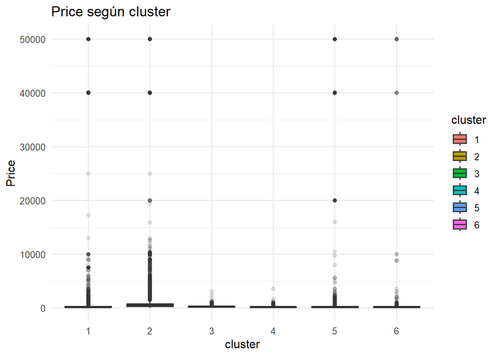

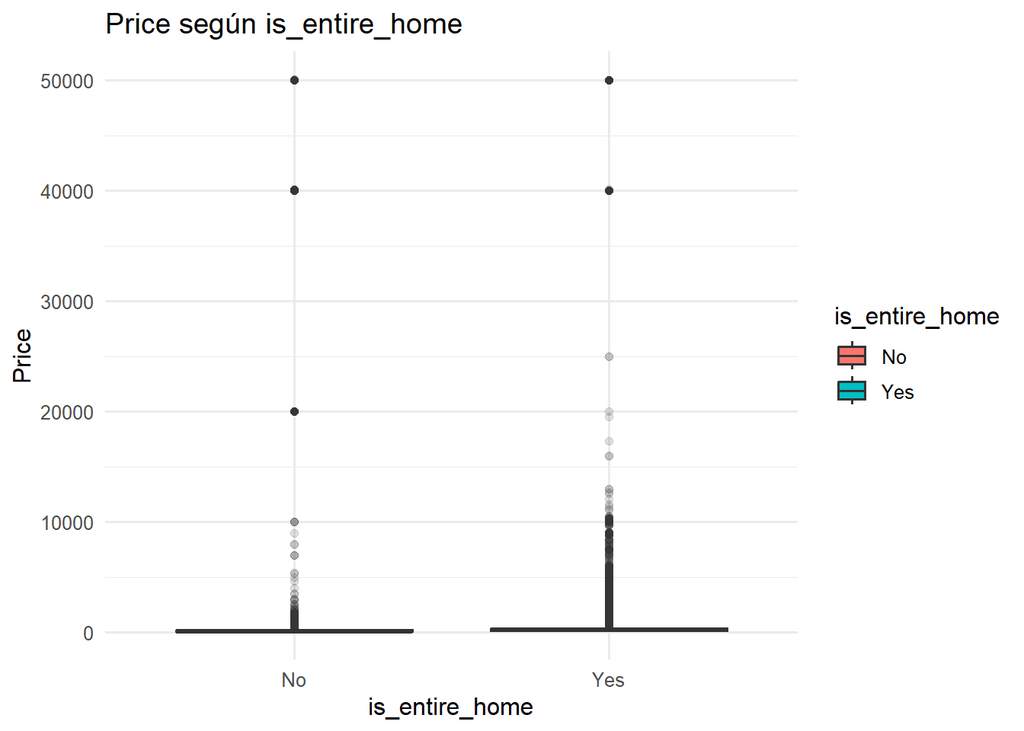

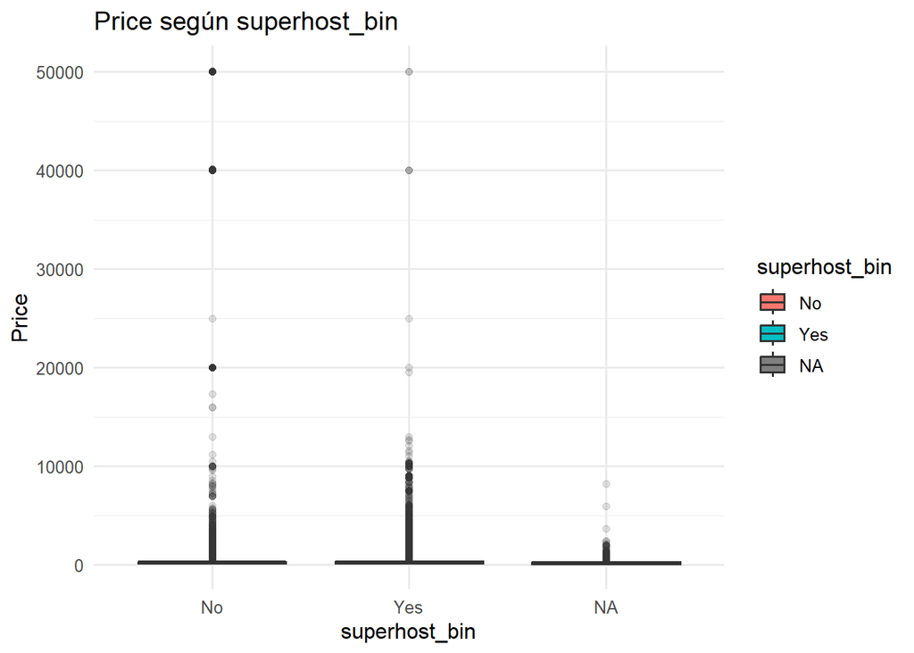

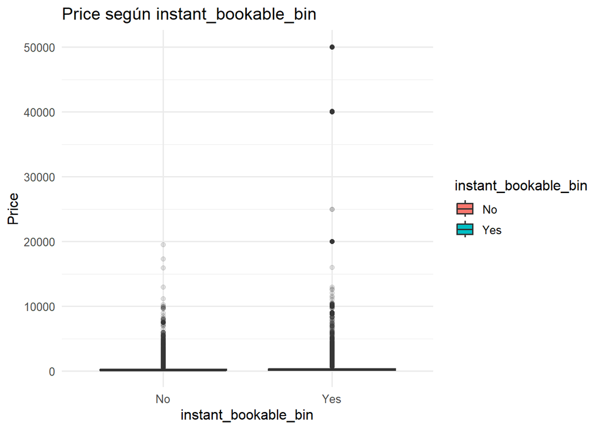

```r
new_cat_vars <- intersect(
  c("cluster", "is_entire_home", "superhost_bin", "instant_bookable_bin"),
  names(listings_fe)
)

for (v in new_cat_vars) {
  p <- ggplot(listings_fe, aes(x = .data[[v]], y = price, fill = .data[[v]])) +
    geom_boxplot(outlier.alpha = 0.15) +
    labs(title = paste("Price según", v), x = v, y = "Price")

  print(p)
}
```

```r
exclude_model_vars <- intersect(
  c(
    "id", "host_id", "listing_url", "picture_url", "host_url",
    "host_picture_url", "host_thumbnail_url", "name", "description",
    "host_about", "neighborhood_overview", "bathrooms_text",
    "bathrooms_text_num",
    "host_name", "license", "host_location", "host_neighbourhood",
    "estimated_revenue_l365d",
    "estimated_occupancy_l365d"
  ),
  names(listings_fe)
)

exclude_model_vars
```

```
## [1] "bathrooms_text_num"        "host_name"
## [3] "license"                   "host_location"
## [5] "host_neighbourhood"        "estimated_revenue_l365d"
## [7] "estimated_occupancy_l365d"
```

```r
model_data <- listings_fe %>%
  select(-any_of(exclude_model_vars))

glimpse(model_data)
```

```
## Rows: 170,127
## Columns: 68
## $ last_scraped                                 <date> 2025-09-17, 2025-09-17, …
## $ source                                       <chr> "city scrape", "city scra…
## $ host_since                                   <date> 2009-02-16, 2009-04-20, …
## $ host_response_time                           <chr> "within a few hours", "wi…
## $ host_response_rate                           <dbl> 1.00, 1.00, 1.00, 1.00, 1…
## $ host_acceptance_rate                         <dbl> 0.90, 0.96, 0.60, 0.91, 0…
## $ host_is_superhost                            <chr> "t", "t", "f", "t", "t", …
## $ host_listings_count                          <int> 1, 1, 1, 2, 1, 1, 1, 1, 1…
## $ host_total_listings_count                    <int> 2, 2, 1, 2, 1, 1, 2, 2, 2…
## $ host_verifications                           <chr> "['email', 'phone']", "['…
## $ host_has_profile_pic                         <chr> "t", "t", "t", "t", "t", …
## $ host_identity_verified                       <chr> "t", "t", "f", "t", "t", …
## $ neighbourhood                                <chr> "Neighborhood highlights"…
```

[output cut: 55 more lines]

La ingeniería de características realizada es consistente con los hallazgos del análisis exploratorio y se integra adecuadamente con las etapas posteriores de partición y modelado. En particular, se incorporaron variables derivadas que resumen mejor el tamaño efectivo y la estructura del alojamiento, como bedrooms_x_bathrooms y accommodates_x_bathrooms, además de variables categóricas compactas como is_entire_home y cluster. Entre las nuevas variables numéricas, las más prometedoras fueron accommodates_x_bathrooms y bedrooms_x_bathrooms, con correlaciones de Spearman de 0.608 y 0.531 respectivamente, superiores incluso a varias variables originales. Esto respalda la idea de que el precio no depende únicamente de la capacidad o del número de habitaciones por separado, sino de la combinación entre capacidad y nivel de infraestructura del alojamiento. En cambio, variables como guests_per_bedroom y bathrooms_per_bedroom mostraron relaciones mucho más débiles con el precio, por lo que parecen menos útiles como predictores principales. También se justificó excluir variables con alta cardinalidad, redundancia o posible fuga de información, como bathrooms_text_num, license, host_location, host_neighbourhood, estimated_revenue_l365d y estimated_occupancy_l365d. En conjunto, esta etapa deja una base coherente para el modelado, priorizando variables interpretables, informativas y estadísticamente más estables.

# Partición reproducible de entrenamiento y prueba

```r
set.seed(123)

model_base <- listings_fe %>%
  select(price, log_price, accommodates) %>%
  drop_na()

n <- nrow(model_base)
train_id <- sample(seq_len(n), size = floor(0.80 * n))

train_data <- model_base[train_id, ]
test_data  <- model_base[-train_id, ]

dim(train_data)
```

```
## [1] 60340     3
```

```r
dim(test_data)
```

```
## [1] 15086     3
```

# Modelo univariado de regresión lineal

Para el modelo univariado se seleccionó la variable accommodates, ya que fue la variable original con mayor asociación monotónica con el precio dentro del análisis exploratorio. Además, su interpretación es directa: representa la capacidad máxima de huéspedes que puede alojar la propiedad, una característica estrechamente relacionada con el tamaño y, por tanto, con el valor esperado del anuncio. Aunque variables derivadas como accommodates_x_bathrooms mostraron una asociación incluso mayor, se eligió accommodates porque resulta más simple de interpretar y es adecuada para un primer modelo univariado.

Dado que la variable price presenta una distribución fuertemente sesgada a la derecha, el modelo se ajustó sobre log_price en lugar de price directamente. Esta decisión se basa en que la transformación logarítmica redujo considerablemente la asimetría observada en la variable respuesta, mejorando la adecuación de los supuestos del modelo lineal y haciendo más estable la relación con la variable explicativa.

```r
lm_uni <- lm(log_price ~ accommodates, data = train_data)

summary(lm_uni)
```

```
##
## Call:
## lm(formula = log_price ~ accommodates, data = train_data)
##
## Residuals:
##     Min      1Q  Median      3Q     Max
## -5.1966 -0.4645 -0.0860  0.3460  5.9353
##
## Coefficients:
##              Estimate Std. Error t value            Pr(>|t|)
## (Intercept)  4.543520   0.006411   708.7 <0.0000000000000002 ***
## accommodates 0.170780   0.001129   151.3 <0.0000000000000002 ***
## ---
## Signif. codes:  0 '***' 0.001 '**' 0.01 '*' 0.05 '.' 0.1 ' ' 1
##
## Residual standard error: 0.8287 on 60338 degrees of freedom
## Multiple R-squared:  0.2751, Adjusted R-squared:  0.2751
## F-statistic: 2.29e+04 on 1 and 60338 DF,  p-value: < 0.00000000000000022
```

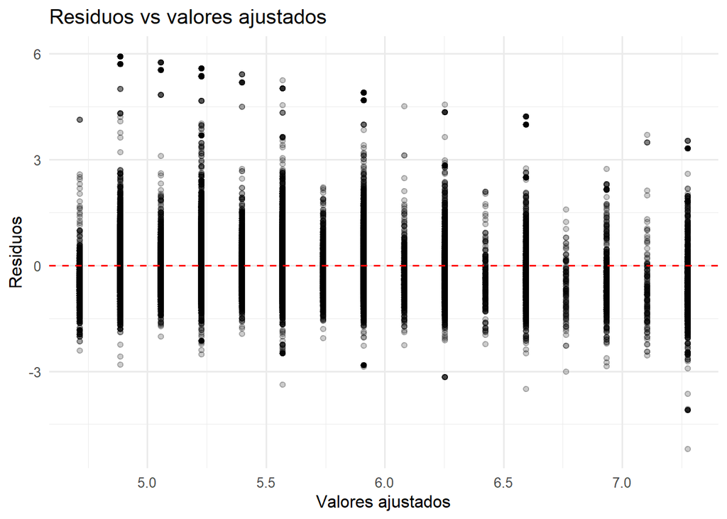

```r
# Residuos y valores ajustados
augment_uni <- broom::augment(lm_uni)

# Gráfico residuos vs ajustados
ggplot(augment_uni, aes(x = .fitted, y = .resid)) +
  geom_point(alpha = 0.2) +
  geom_hline(yintercept = 0, linetype = 2, color = "red") +
  labs(
    title = "Residuos vs valores ajustados",
    x = "Valores ajustados",
    y = "Residuos"
  )
```

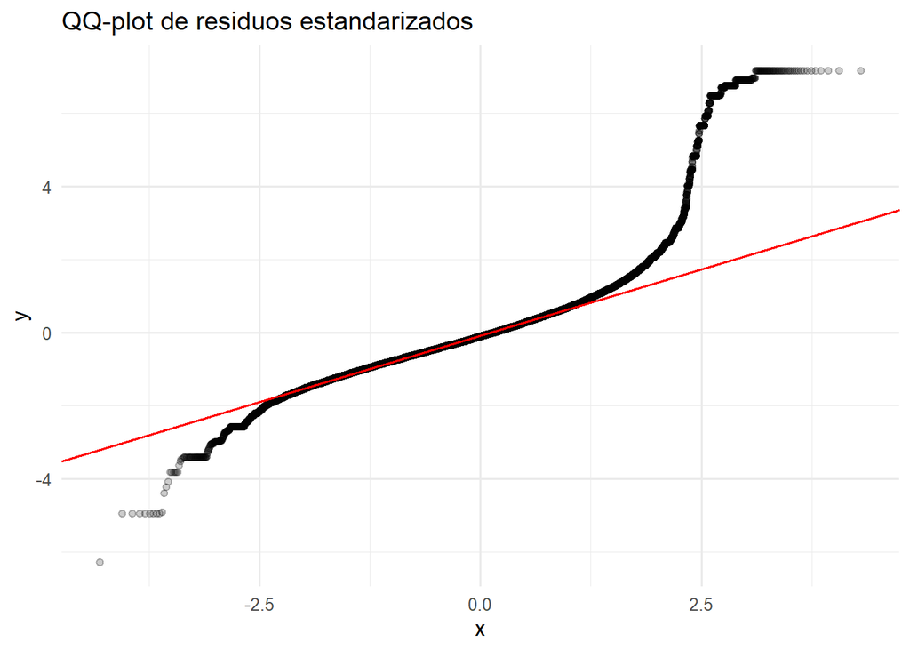

```r
# QQ-plot de residuos
ggplot(augment_uni, aes(sample = .std.resid)) +
  stat_qq(alpha = 0.2) +
  stat_qq_line(color = "red") +
  labs(title = "QQ-plot de residuos estandarizados")
```

El análisis de residuos muestra que el modelo mejora respecto a trabajar con price en escala original, pero todavía no cumple perfectamente todos los supuestos clásicos de la regresión lineal. En el gráfico de residuos contra valores ajustados se observa una dispersión relativamente centrada en cero, pero con patrones de variabilidad no completamente homogéneos y presencia de residuos extremos. Además, el QQ-plot evidencia desviaciones claras en las colas, lo que indica que los residuos no siguen una distribución normal estricta. Esto era esperable, dado que el mercado de alojamientos presenta una fuerte heterogeneidad, valores atípicos muy altos y segmentos distintos de propiedades. En consecuencia, el modelo univariado puede considerarse útil como una primera aproximación explicativa, pero no como un modelo final suficiente para capturar toda la complejidad del precio

```r
test_pred <- test_data %>%
  mutate(
    pred_log_price = predict(lm_uni, newdata = test_data),
    pred_price = exp(pred_log_price)
  )

# Métricas en escala original
rmse <- sqrt(mean((test_pred$price - test_pred$pred_price)^2, na.rm = TRUE))
mae  <- mean(abs(test_pred$price - test_pred$pred_price), na.rm = TRUE)

tibble(
  RMSE = rmse,
  MAE = mae
)
```

```
## # A tibble: 1 × 2
##    RMSE   MAE
##   <dbl> <dbl>
## 1 4059.  555.
```

```r
test_pred %>%
  select(price, pred_price, accommodates) %>%
  slice_head(n = 10)
```

```
## # A tibble: 10 × 3
##    price pred_price accommodates
##    <dbl>      <dbl>        <int>
##  1   145       157.            3
##  2   103       157.            3
##  3    86       112.            1
##  4    51       132.            2
##  5   236       262.            6
##  6   120       132.            2
##  7   136       186.            4
##  8   358       221.            5
##  9   150       262.            6
## 10   138       186.            4
```

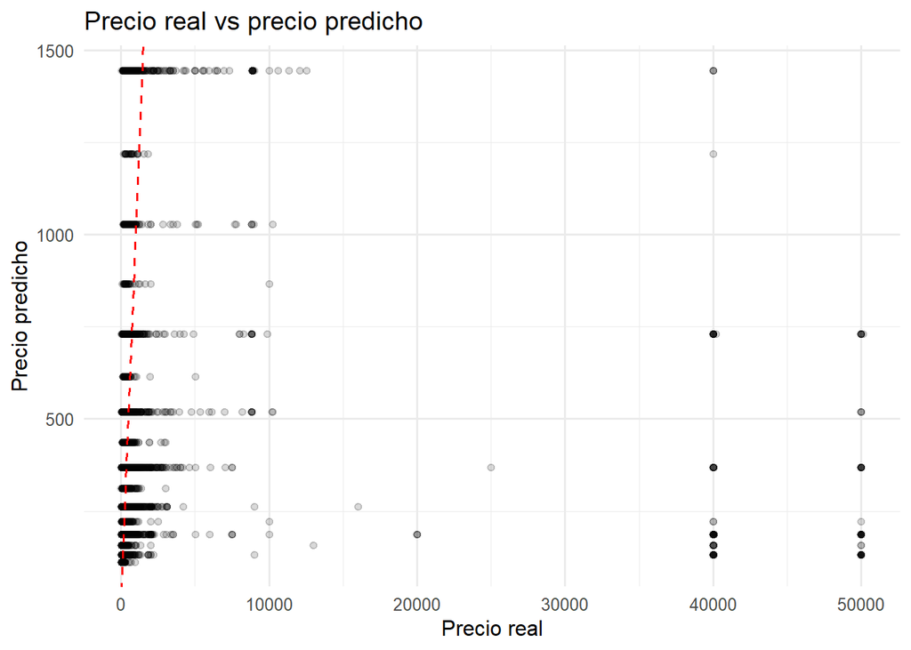

```r
ggplot(test_pred, aes(x = price, y = pred_price)) +
  geom_point(alpha = 0.15) +
  geom_abline(slope = 1, intercept = 0, linetype = 2, color = "red") +
  labs(
    title = "Precio real vs precio predicho",
    x = "Precio real",
    y = "Precio predicho"
  )
```

# 9 Análisis del modelo: multicolinealidad, correlación, ajuste y sobreajuste:

```r
library(dplyr)
library(tidyr)

if (!"minimum_nights" %in% names(listings_fe)) {
  stop("La columna 'minimum_nights' no existe en listings_fe")
}

model_base_mv <- listings_fe %>%
  mutate(
    room_type = as.factor(room_type),
    city = as.factor(city),
    instant_bookable_bin = as.factor(instant_bookable_bin),
    log_minimum_nights = log1p(minimum_nights)
  ) %>%
  select(
    price, log_price,
    accommodates, bedrooms, beds, bathrooms,
    log_minimum_nights, review_scores_rating,
    room_type, city, instant_bookable_bin
  ) %>%
  drop_na()

set.seed(123)
n_mv <- nrow(model_base_mv)
train_id_mv <- sample(seq_len(n_mv), size = floor(0.80 * n_mv))

train_mv <- model_base_mv[train_id_mv, ]
test_mv  <- model_base_mv[-train_id_mv, ]

lm_full <- lm(
  log_price ~ accommodates + bedrooms + beds + bathrooms +
    log_minimum_nights + review_scores_rating +
    room_type + city + instant_bookable_bin,
  data = train_mv
)

summary(lm_full)
```

```
##
## Call:
## lm(formula = log_price ~ accommodates + bedrooms + beds + bathrooms +
##     log_minimum_nights + review_scores_rating + room_type + city +
##     instant_bookable_bin, data = train_mv)
##
## Residuals:
##     Min      1Q  Median      3Q     Max
## -5.2229 -0.3453 -0.0585  0.2735  6.5550
##
## Coefficients:
##                            Estimate Std. Error t value            Pr(>|t|)
## (Intercept)                3.392492   0.042079   80.62 <0.0000000000000002 ***
## accommodates               0.089559   0.002118   42.29 <0.0000000000000002 ***
## bedrooms                   0.079046   0.004382   18.04 <0.0000000000000002 ***
## beds                      -0.032624   0.002705  -12.06 <0.0000000000000002 ***
## bathrooms                  0.213642   0.004695   45.50 <0.0000000000000002 ***
## log_minimum_nights        -0.051769   0.002975  -17.40 <0.0000000000000002 ***
## review_scores_rating       0.149240   0.008344   17.89 <0.0000000000000002 ***
## room_typeHotel room        2.211593   0.046441   47.62 <0.0000000000000002 ***
## room_typePrivate room     -0.369599   0.009029  -40.93 <0.0000000000000002 ***
## room_typeShared room      -1.246177   0.051303  -24.29 <0.0000000000000002 ***
## cityBoston, Massachusetts  0.670884   0.014827   45.25 <0.0000000000000002 ***
## cityChicago, Illinois      0.202363   0.011169   18.12 <0.0000000000000002 ***
## cityHawaii                 0.618848   0.008467   73.09 <0.0000000000000002 ***
## cityRhode Island           0.643992   0.012505   51.50 <0.0000000000000002 ***
## citySan Diego, California  0.349583   0.009931   35.20 <0.0000000000000002 ***
## cityWashington, D.C.       0.185036   0.012634   14.65 <0.0000000000000002 ***
## instant_bookable_binYes    0.088767   0.005720   15.52 <0.0000000000000002 ***
## ---
## Signif. codes:  0 '***' 0.001 '**' 0.01 '*' 0.05 '.' 0.1 ' ' 1
##
## Residual standard error: 0.6009 on 50160 degrees of freedom
## Multiple R-squared:  0.488,  Adjusted R-squared:  0.4879
## F-statistic:  2989 on 16 and 50160 DF,  p-value: < 0.00000000000000022
```

# Multicolinealidad

```r
vif_full_raw <- car::vif(lm_full)

vif_full <- if (is.matrix(vif_full_raw)) {
  as_tibble(vif_full_raw, rownames = "variable") %>%
    mutate(GVIF_ajustado = GVIF^(1 / (2 * Df))) %>%
    arrange(desc(GVIF_ajustado))
} else {
  tibble(variable = names(vif_full_raw), VIF = as.numeric(vif_full_raw)) %>%
    arrange(desc(VIF))
}

vif_full
```

```
## # A tibble: 9 × 5
##   variable              GVIF    Df `GVIF^(1/(2*Df))` GVIF_ajustado
##   <chr>                <dbl> <dbl>             <dbl>         <dbl>
## 1 accommodates          5.43     1              2.33          2.33
## 2 bedrooms              4.62     1              2.15          2.15
## 3 beds                  4.07     1              2.02          2.02
## 4 bathrooms             2.55     1              1.60          1.60
## 5 instant_bookable_bin  1.12     1              1.06          1.06
## 6 log_minimum_nights    1.12     1              1.06          1.06
## 7 room_type             1.21     3              1.03          1.03
## 8 city                  1.26     6              1.02          1.02
## 9 review_scores_rating  1.03     1              1.02          1.02
```

# Variables que aportan al modelo

```r
drop1(lm_full, test = "F")
```

```
## Single term deletions
##
## Model:
## log_price ~ accommodates + bedrooms + beds + bathrooms + log_minimum_nights +
##     review_scores_rating + room_type + city + instant_bookable_bin
##                      Df Sum of Sq   RSS    AIC F value                Pr(>F)
## <none>                            18114 -51090
## accommodates          1    645.78 18760 -49334 1788.23 < 0.00000000000000022
## bedrooms              1    117.49 18232 -50767  325.35 < 0.00000000000000022
## beds                  1     52.54 18167 -50946  145.50 < 0.00000000000000022
## bathrooms             1    747.76 18862 -49062 2070.63 < 0.00000000000000022
## log_minimum_nights    1    109.32 18223 -50790  302.72 < 0.00000000000000022
## review_scores_rating  1    115.53 18230 -50773  319.92 < 0.00000000000000022
## room_type             3   1645.59 19760 -46733 1518.95 < 0.00000000000000022
## city                  6   2745.72 20860 -44020 1267.21 < 0.00000000000000022
## instant_bookable_bin  1     86.96 18201 -50852  240.81 < 0.00000000000000022
##
## <none>
## accommodates         ***
## bedrooms             ***
## beds                 ***
## bathrooms            ***
## log_minimum_nights   ***
## review_scores_rating ***
## room_type            ***
## city                 ***
## instant_bookable_bin ***
## ---
## Signif. codes:  0 '***' 0.001 '**' 0.01 '*' 0.05 '.' 0.1 ' ' 1
```

# Correlación entre las características del modelo

```r
num_model_vars <- train_mv %>%
  select(accommodates, bedrooms, beds, bathrooms,
         log_minimum_nights, review_scores_rating)

cor_mat_mv <- cor(num_model_vars, use = "pairwise.complete.obs")
cor_mat_mv
```

```
##                      accommodates     bedrooms        beds   bathrooms
## accommodates           1.00000000  0.830989159  0.85310467  0.70026364
## bedrooms               0.83098916  1.000000000  0.79105589  0.74991731
## beds                   0.85310467  0.791055892  1.00000000  0.66604566
## bathrooms              0.70026364  0.749917310  0.66604566  1.00000000
## log_minimum_nights    -0.11563744 -0.007493469 -0.07422256 -0.01756211
## review_scores_rating   0.06165937  0.076896155  0.06353660  0.05349995
##                      log_minimum_nights review_scores_rating
## accommodates               -0.115637437           0.06165937
## bedrooms                   -0.007493469           0.07689615
## beds                       -0.074222559           0.06353660
## bathrooms                  -0.017562114           0.05349995
## log_minimum_nights          1.000000000          -0.02231636
## review_scores_rating       -0.022316357           1.00000000
```

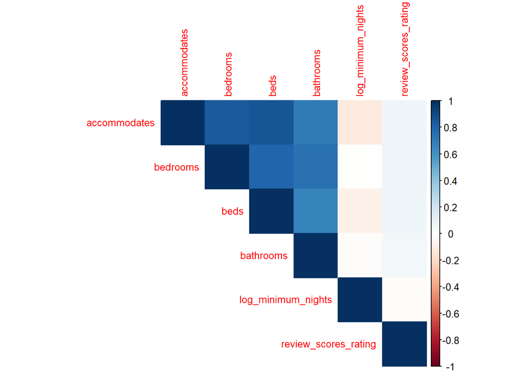

```r
corrplot::corrplot(
  cor_mat_mv,
  method = "color",
  type = "upper",
  tl.cex = 0.8,
  number.cex = 0.7
)
```

# Métricas train/test para detectar sobreajuste

```r
eval_model <- function(model, data, split_name) {
  pred_log <- predict(model, newdata = data)
  pred_price <- exp(pred_log)

  tibble(
    split = split_name,
    RMSE_log = sqrt(mean((data$log_price - pred_log)^2, na.rm = TRUE)),
    MAE_log  = mean(abs(data$log_price - pred_log), na.rm = TRUE),
    RMSE_price = sqrt(mean((data$price - pred_price)^2, na.rm = TRUE)),
    MAE_price  = mean(abs(data$price - pred_price), na.rm = TRUE))
}

metrics_full <- bind_rows(
  eval_model(lm_full, train_mv, "train"),
  eval_model(lm_full, test_mv, "test")
)

metrics_full
```

```
## # A tibble: 2 × 5
##   split RMSE_log MAE_log RMSE_price MAE_price
##   <chr>    <dbl>   <dbl>      <dbl>     <dbl>
## 1 train    0.601   0.415      2467.      261.
## 2 test     0.597   0.414      2444.      256.
```

# Análisis de residuos del modelo inicial

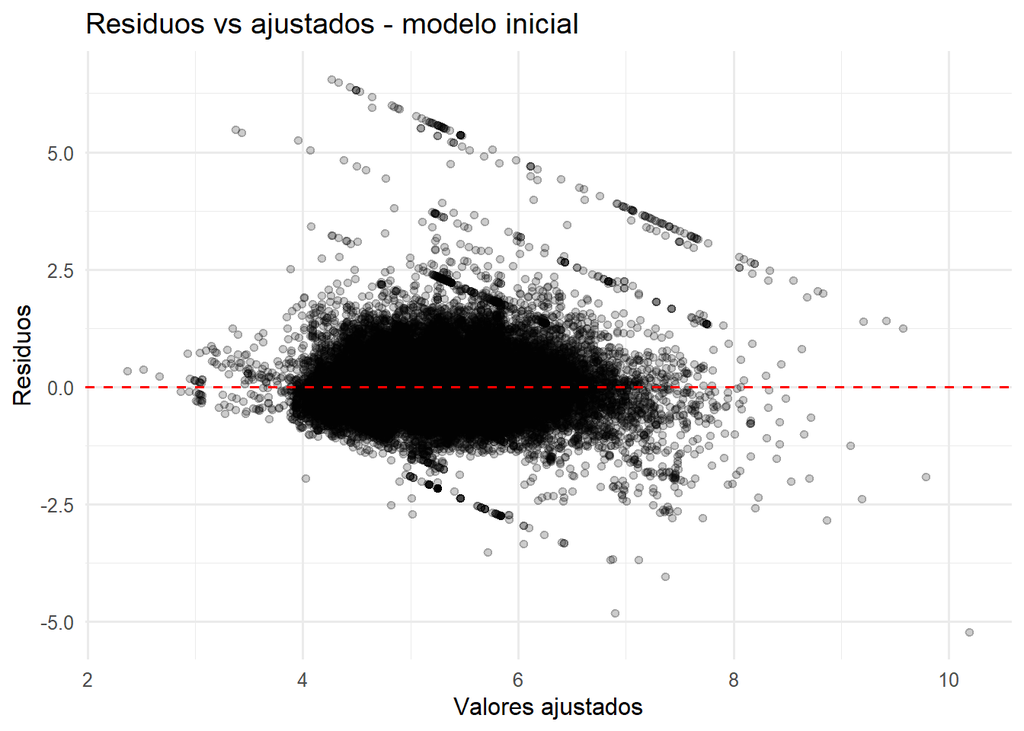

```r
aug_full <- broom::augment(lm_full)

ggplot(aug_full, aes(x = .fitted, y = .resid)) +
  geom_point(alpha = 0.2) +
  geom_hline(yintercept = 0, linetype = 2, color = "red") +
  labs(
    title = "Residuos vs ajustados - modelo inicial",
    x = "Valores ajustados",
    y = "Residuos"
  )
```

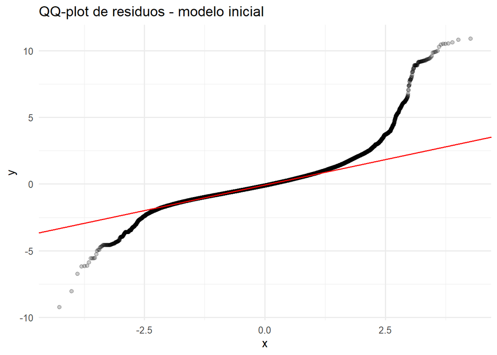

```r
ggplot(aug_full, aes(sample = .std.resid)) +
  stat_qq(alpha = 0.2) +
  stat_qq_line(color = "red") +
  labs(title = "QQ-plot de residuos - modelo inicial")
```

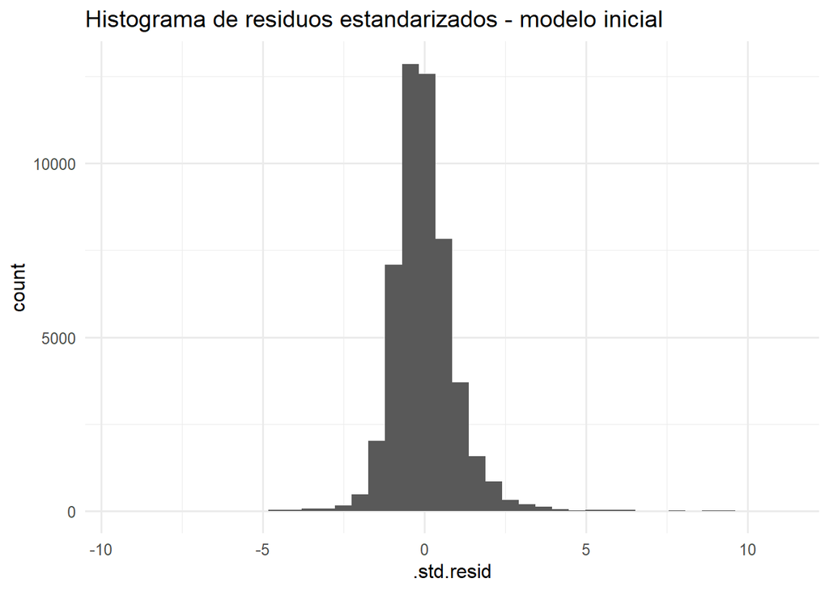

```r
ggplot(aug_full, aes(x = .std.resid)) +
  geom_histogram(bins = 40) +
  labs(title = "Histograma de residuos estandarizados - modelo inicial")
```

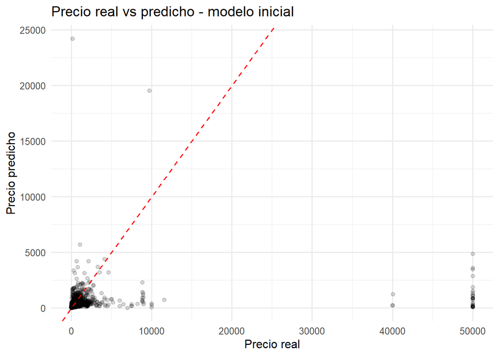

```r
test_pred_full <- test_mv %>%
  mutate(
    pred_log_price = predict(lm_full, newdata = test_mv),
    pred_price = exp(pred_log_price)
  )

ggplot(test_pred_full, aes(x = price, y = pred_price)) +
  geom_point(alpha = 0.15) +
  geom_abline(slope = 1, intercept = 0, linetype = 2, color = "red") +
  labs(
    title = "Precio real vs predicho - modelo inicial",
    x = "Precio real",
    y = "Precio predicho"
  )
```

El modelo lineal múltiple para log_price resulta globalmente significativo y presenta un ajuste moderado, con R^2 ajustado de 0.4879, por lo que explica cerca del 48.8% de la variabilidad del precio en escala logarítmica. En cuanto a multicolinealidad, aunque existe correlación relativamente alta entre las variables asociadas al tamaño y capacidad del alojamiento —especialmente accommodates, bedrooms, beds y bathrooms (correlaciones entre 0.67 y 0.85)—, los valores de VIF/GVIF ajustado se mantienen en rangos aceptables, con un máximo cercano a 2.33, por lo que no se observa multicolinealidad severa. El análisis drop1() muestra que todas las variables aportan significativamente al modelo, destacándose por su contribución city, room_type, bathrooms y accommodates. Respecto al ajuste, los gráficos de residuos indican que el modelo capta razonablemente la tendencia general de los datos, aunque no de forma perfecta: se observan ciertos outliers, colas pesadas y algo de heterocedasticidad, por lo que no se cumplen completamente los supuestos clásicos de normalidad y varianza constante. Sin embargo, al comparar métricas de entrenamiento y prueba no hay evidencia de sobreajuste, ya que los errores son prácticamente iguales en ambos conjuntos (RMSE_log: 0.6008 en train vs. 0.5972 en test; MAE_log: 0.4154 vs. 0.4137), e incluso el desempeño en test es levemente mejor. En consecuencia, el modelo no presenta overfitting y no es necesario construir otro para corregirlo, aunque podría refinarse para mejorar el tratamiento de valores extremos y la dispersión residual.

# 10 Modelo corregido si hay multicolinealidad o sobreajuste:

En esta sección se comparan dos especificaciones del modelo lineal: un modelo completo y un modelo reducido. El modelo reducido elimina la variable beds, ya que presenta solapamiento con otras variables asociadas al tamaño del alojamiento, como accommodates y bedrooms. El objetivo es evaluar si un modelo más parsimonioso mantiene una capacidad predictiva similar.

```r
lm_full <- lm(
  log_price ~ accommodates + bedrooms + beds + bathrooms +
    log_minimum_nights + review_scores_rating +
    room_type + city + instant_bookable_bin,
  data = train_mv
)
lm_red <- lm(
  log_price ~ accommodates + bedrooms + bathrooms +
    log_minimum_nights + review_scores_rating +
    room_type + city + instant_bookable_bin,
  data = train_mv
)

summary(lm_red)
```

```
##
## Call:
## lm(formula = log_price ~ accommodates + bedrooms + bathrooms +
##     log_minimum_nights + review_scores_rating + room_type + city +
##     instant_bookable_bin, data = train_mv)
##
## Residuals:
##     Min      1Q  Median      3Q     Max
## -4.6945 -0.3451 -0.0596  0.2730  6.5858
##
## Coefficients:
##                            Estimate Std. Error t value            Pr(>|t|)
## (Intercept)                3.403876   0.042129   80.80 <0.0000000000000002 ***
## accommodates               0.075765   0.001785   42.44 <0.0000000000000002 ***
## bedrooms                   0.067055   0.004274   15.69 <0.0000000000000002 ***
## bathrooms                  0.210258   0.004693   44.80 <0.0000000000000002 ***
## log_minimum_nights        -0.051848   0.002980  -17.40 <0.0000000000000002 ***
## review_scores_rating       0.148491   0.008356   17.77 <0.0000000000000002 ***
## room_typeHotel room        2.245856   0.046421   48.38 <0.0000000000000002 ***
## room_typePrivate room     -0.371457   0.009041  -41.09 <0.0000000000000002 ***
## room_typeShared room      -1.284081   0.051280  -25.04 <0.0000000000000002 ***
## cityBoston, Massachusetts  0.669070   0.014848   45.06 <0.0000000000000002 ***
## cityChicago, Illinois      0.207007   0.011178   18.52 <0.0000000000000002 ***
## cityHawaii                 0.615794   0.008476   72.65 <0.0000000000000002 ***
## cityRhode Island           0.640872   0.012521   51.19 <0.0000000000000002 ***
## citySan Diego, California  0.349654   0.009945   35.16 <0.0000000000000002 ***
## cityWashington, D.C.       0.185664   0.012652   14.67 <0.0000000000000002 ***
## instant_bookable_binYes    0.089317   0.005728   15.59 <0.0000000000000002 ***
## ---
## Signif. codes:  0 '***' 0.001 '**' 0.01 '*' 0.05 '.' 0.1 ' ' 1
##
## Residual standard error: 0.6018 on 50161 degrees of freedom
## Multiple R-squared:  0.4866, Adjusted R-squared:  0.4864
## F-statistic:  3169 on 15 and 50161 DF,  p-value: < 0.00000000000000022
```

A continuación, se calculan métricas de desempeño para comparar ambos modelos en los conjuntos de entrenamiento y prueba. Se utilizan RMSE y MAE tanto en escala logarítmica como en escala original del precio, con el fin de verificar si el modelo reducido conserva una precisión similar y si existe evidencia de sobreajuste.

```r
eval_model <- function(model, data, split_name, model_name) {
  pred_log <- predict(model, newdata = data)
  pred_price <- exp(pred_log)

  tibble(
    model = model_name,
    split = split_name,
    RMSE_log = sqrt(mean((data$log_price - pred_log)^2, na.rm = TRUE)),
    MAE_log = mean(abs(data$log_price - pred_log), na.rm = TRUE),
    RMSE_price = sqrt(mean((data$price - pred_price)^2, na.rm = TRUE)),
    MAE_price = mean(abs(data$price - pred_price), na.rm = TRUE)
  )
}

metrics_compare <- bind_rows(
  eval_model(lm_full, train_mv, "train", "completo"),
  eval_model(lm_full, test_mv,  "test",  "completo"),
  eval_model(lm_red,  train_mv, "train", "reducido"),
  eval_model(lm_red,  test_mv,  "test",  "reducido")
)

metrics_compare
```

```
## # A tibble: 4 × 6
##   model    split RMSE_log MAE_log RMSE_price MAE_price
##   <chr>    <chr>    <dbl>   <dbl>      <dbl>     <dbl>
## 1 completo train    0.601   0.415      2467.      261.
## 2 completo test     0.597   0.414      2444.      256.
## 3 reducido train    0.602   0.415      2473.      262.
## 4 reducido test     0.598   0.414      2443.      257.
```

En este bloque se evalúa la multicolinealidad de los modelos mediante el factor de inflación de la varianza (VIF). Para variables categóricas se utiliza el GVIF ajustado. Esta comparación permite verificar si el modelo reducido disminuye la dependencia lineal entre predictores sin afectar de manera importante el ajuste.

```r
get_vif_table <- function(model) {
  vif_raw <- car::vif(model)

  if (is.matrix(vif_raw)) {
    as_tibble(vif_raw, rownames = "variable") %>%
      mutate(VIF_ajustado = GVIF^(1 / (2 * Df))) %>%
      arrange(desc(VIF_ajustado))
  } else {
    tibble(variable = names(vif_raw), VIF = as.numeric(vif_raw)) %>%
      arrange(desc(VIF))
  }
}

vif_full_tbl <- get_vif_table(lm_full)
vif_red_tbl  <- get_vif_table(lm_red)

vif_full_tbl
```

```
## # A tibble: 9 × 5
##   variable              GVIF    Df `GVIF^(1/(2*Df))` VIF_ajustado
##   <chr>                <dbl> <dbl>             <dbl>        <dbl>
## 1 accommodates          5.43     1              2.33         2.33
## 2 bedrooms              4.62     1              2.15         2.15
## 3 beds                  4.07     1              2.02         2.02
## 4 bathrooms             2.55     1              1.60         1.60
## 5 instant_bookable_bin  1.12     1              1.06         1.06
## 6 log_minimum_nights    1.12     1              1.06         1.06
## 7 room_type             1.21     3              1.03         1.03
## 8 city                  1.26     6              1.02         1.02
## 9 review_scores_rating  1.03     1              1.02         1.02
```

```r
vif_red_tbl
```

```
## # A tibble: 8 × 5
##   variable              GVIF    Df `GVIF^(1/(2*Df))` VIF_ajustado
##   <chr>                <dbl> <dbl>             <dbl>        <dbl>
## 1 bedrooms              4.38     1              2.09         2.09
## 2 accommodates          3.85     1              1.96         1.96
## 3 bathrooms             2.55     1              1.60         1.60
## 4 instant_bookable_bin  1.12     1              1.06         1.06
## 5 log_minimum_nights    1.12     1              1.06         1.06
## 6 room_type             1.20     3              1.03         1.03
## 7 city                  1.26     6              1.02         1.02
## 8 review_scores_rating  1.03     1              1.02         1.02
```

Seguidamente, se realiza un análisis gráfico de residuos para evaluar la calidad del modelo reducido. Se examinan los residuos frente a los valores ajustados, la normalidad mediante QQ-plot, la distribución de residuos estandarizados y la posible heterocedasticidad con el gráfico Scale-Location. Estos gráficos permiten revisar si los supuestos del modelo lineal se cumplen razonablemente.

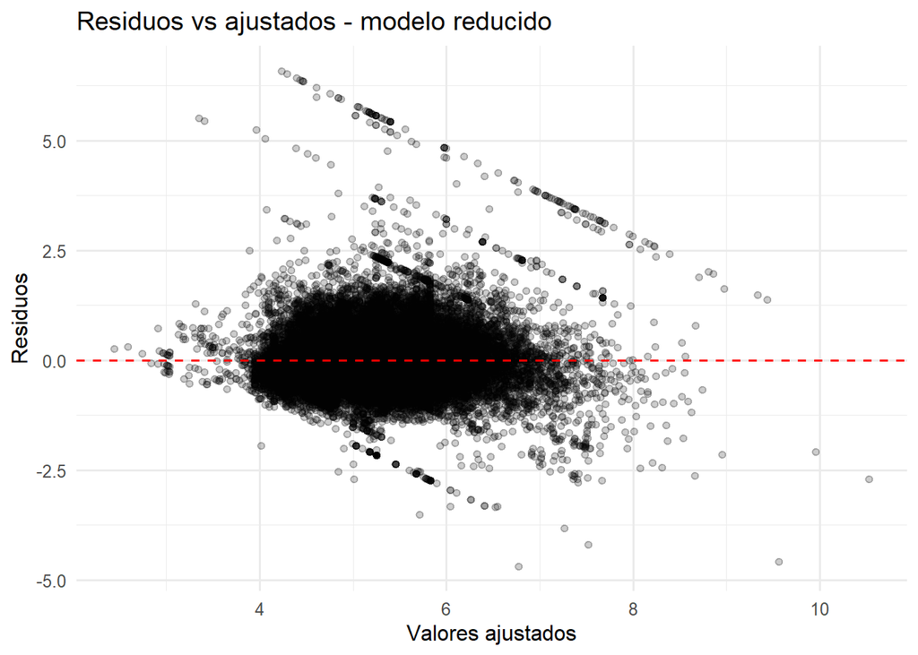

```r
aug_red <- broom::augment(lm_red)

# 1. Residuos vs ajustados
ggplot(aug_red, aes(x = .fitted, y = .resid)) +
  geom_point(alpha = 0.20) +
  geom_hline(yintercept = 0, linetype = 2, color = "red") +
  labs(
    title = "Residuos vs ajustados - modelo reducido",
    x = "Valores ajustados",
    y = "Residuos"
  )
```

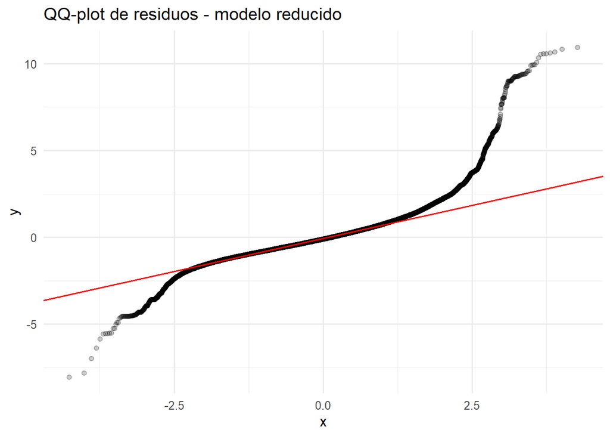

```r
# 2. QQ-plot
ggplot(aug_red, aes(sample = .std.resid)) +
  stat_qq(alpha = 0.20) +
  stat_qq_line(color = "red") +
  labs(title = "QQ-plot de residuos - modelo reducido")
```

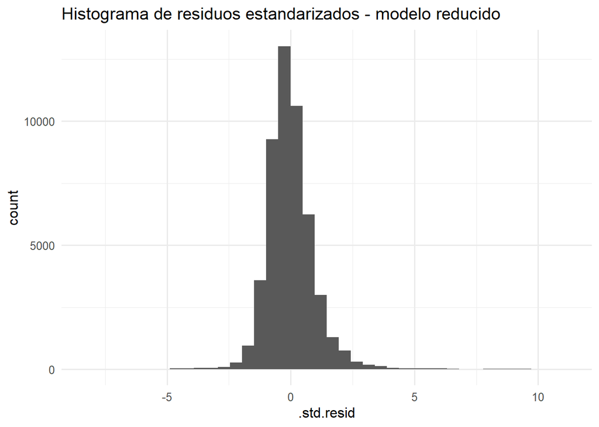

```r
# 3. Histograma de residuos estandarizados
ggplot(aug_red, aes(x = .std.resid)) +
  geom_histogram(bins = 40) +
  labs(title = "Histograma de residuos estandarizados - modelo reducido")
```

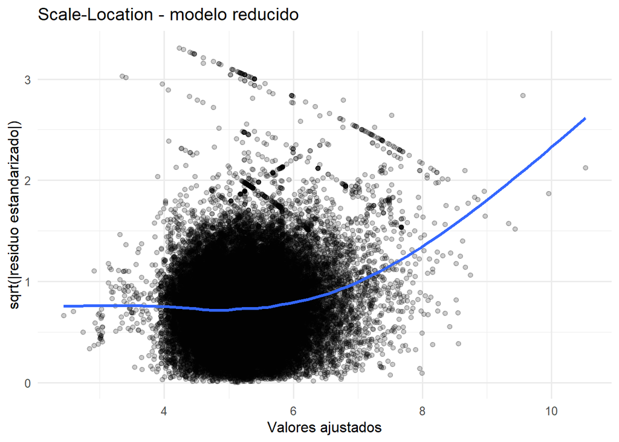

```r
# 4. Scale-Location
ggplot(aug_red, aes(x = .fitted, y = sqrt(abs(.std.resid)))) +
  geom_point(alpha = 0.20) +
  geom_smooth(se = FALSE) +
  labs(
    title = "Scale-Location - modelo reducido",
    x = "Valores ajustados",
    y = "sqrt(|residuo estandarizado|)"
  )
```

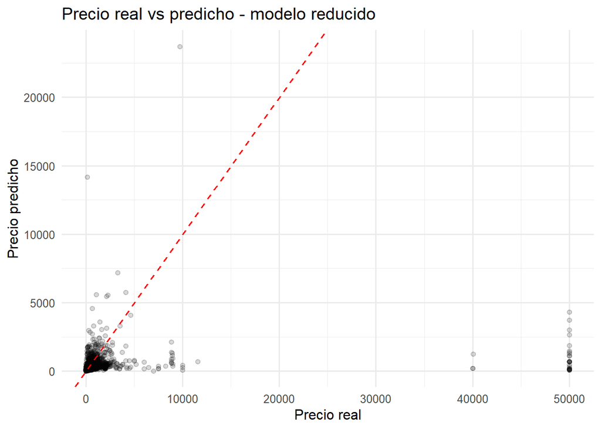

```r
test_pred_red <- test_mv %>%
  mutate(
    pred_log_price = predict(lm_red, newdata = test_mv),
    pred_price = exp(pred_log_price)
  )

ggplot(test_pred_red, aes(x = price, y = pred_price)) +
  geom_point(alpha = 0.15) +
  geom_abline(slope = 1, intercept = 0, linetype = 2, color = "red") +
  labs(
    title = "Precio real vs predicho - modelo reducido",
    x = "Precio real",
    y = "Precio predicho"
  )
```

Para reducir la colinealidad moderada observada entre accommodates, bedrooms y beds, se estimó un modelo reducido eliminando beds. Este nuevo modelo mantiene solo las variables más relevantes para predecir el precio y conserva un desempeño muy similar al modelo completo, con R^2 ajustado de 0.4864 y métricas de entrenamiento y prueba casi iguales, por lo que no presenta evidencia de sobreajuste. Además, los VIF ajustados permanecen en valores bajos, lo que confirma que la multicolinealidad no es severa. El análisis gráfico de residuos muestra que, aunque los residuos están centrados alrededor de cero, existen outliers, colas pesadas y cierta heterocedasticidad, por lo que el ajuste es razonable pero no perfecto. El modelo predice adecuadamente la mayoría de los precios, aunque pierde precisión en propiedades con precios extremadamente altos. Por ello, el modelo reducido se considera una mejor alternativa por ser más parsimonioso e interpretable sin sacrificar capacidad predictiva.

# 11 Modelo con regularización

Para complementar los modelos lineales anteriores, se construye un modelo de regresión con regularización utilizando Lasso. Este tipo de modelo introduce una penalización sobre los coeficientes que permite reducir la complejidad del modelo y seleccionar automáticamente las variables más relevantes para la predicción del precio.

```r
library(glmnet)
```

Preparación de los datos para regularización

Los modelos de regularización requieren que las variables predictoras se representen en forma de matriz numérica.

```r
x_train <- model.matrix(
  log_price ~ accommodates + bedrooms + bathrooms +
    log_minimum_nights + review_scores_rating +
    room_type + city + instant_bookable_bin,
  data = train_mv
)[, -1]

y_train <- train_mv$log_price

x_test <- model.matrix(
  log_price ~ accommodates + bedrooms + bathrooms +
    log_minimum_nights + review_scores_rating +
    room_type + city + instant_bookable_bin,
  data = test_mv
)[, -1]

y_test <- test_mv$log_price
```

Selección del parámetro de regularización

Se utiliza validación cruzada para encontrar el valor óptimo del parámetro de penalización λ.

```r
set.seed(123)

cv_lasso <- cv.glmnet(
  x_train,
  y_train,
  alpha = 1
)

best_lambda <- cv_lasso$lambda.min
best_lambda
```

```
## [1] 0.0006943076
```

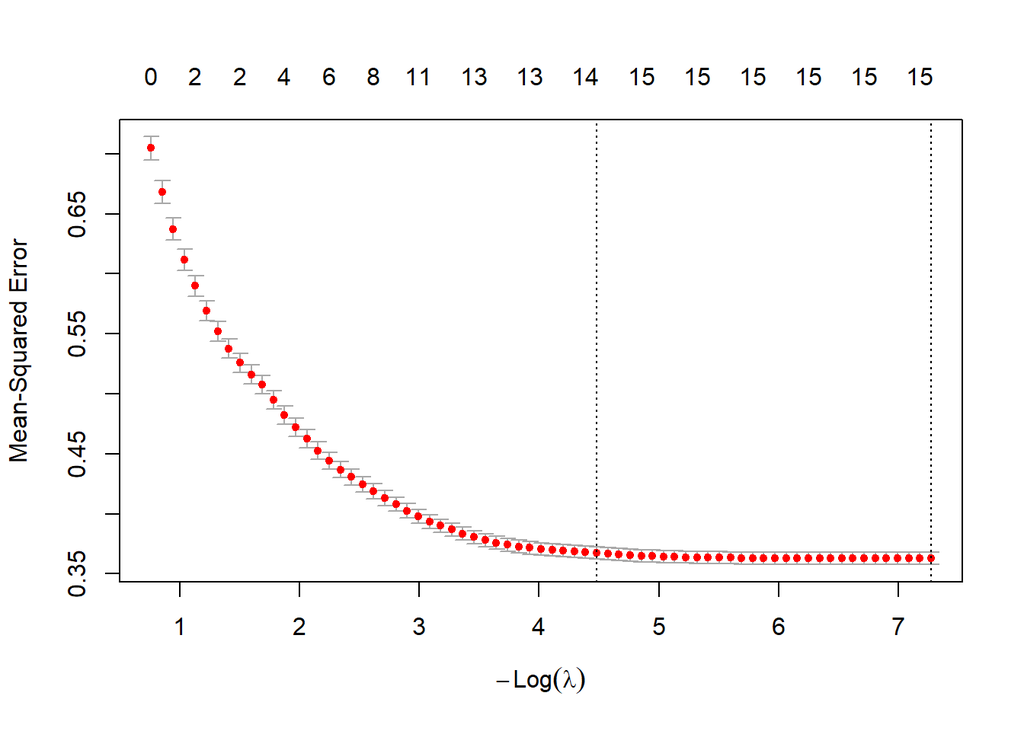

```r
plot(cv_lasso)
```

Ajuste del modelo

```r
lasso_model <- glmnet(
  x_train,
  y_train,
  alpha = 1,
  lambda = best_lambda
)

coef(lasso_model)
```

```
## 19 x 1 sparse Matrix of class "dgCMatrix"
##                                        s0
## (Intercept)                    3.42711101
## accommodates                   0.07565292
## bedrooms                       0.06688358
## bathrooms                      0.20971163
## log_minimum_nights            -0.05099723
## review_scores_rating           0.14586634
## room_typeHotel room            2.23581606
## room_typePrivate room         -0.36984040
## room_typeShared room          -1.27294098
## cityBoston, Massachusetts      0.65459897
## cityChicago, Illinois          0.19449766
## cityHawaii                     0.60537922
## cityLos Angeles, California    .
## cityNew York, New York         .
## cityRhode Island               0.62849455
## citySan Diego, California      0.33813483
## citySan Francisco, California  .
## cityWashington, D.C.           0.17268054
## instant_bookable_binYes        0.08815379
```

Los coeficientes distintos de cero indican las variables que el modelo considera más relevantes para predecir el precio del alojamiento.

Predicciones

```r
pred_log_lasso <- predict(
  lasso_model,
  s = best_lambda,
  newx = x_test
)

pred_price_lasso <- exp(pred_log_lasso)
real_price <- exp(y_test)
```

Comparaciones entre el precio real y el predicho

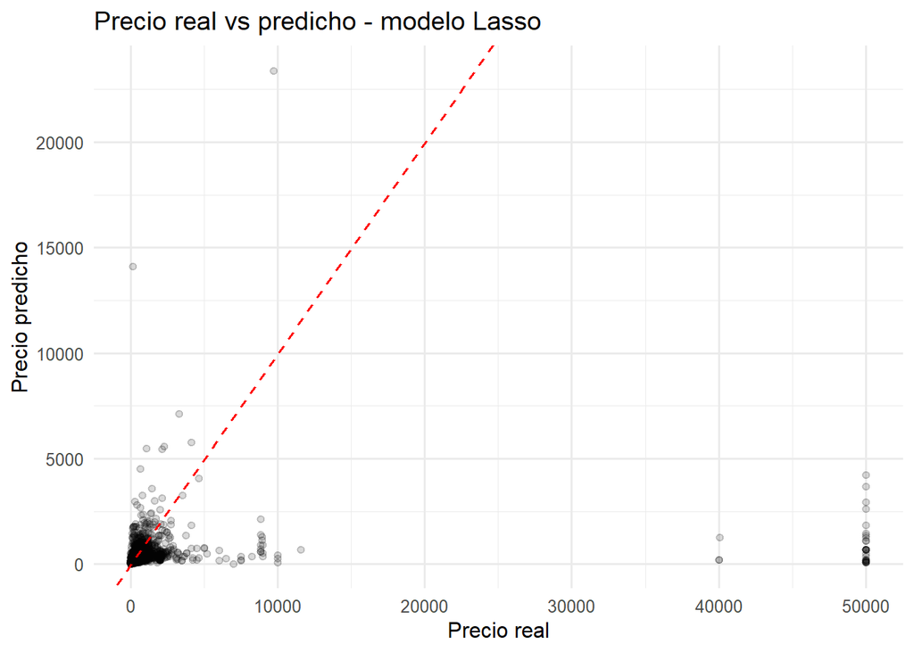

```r
lasso_results <- data.frame(
  real_price = real_price,
  pred_price = as.numeric(pred_price_lasso)
)

ggplot(lasso_results, aes(x = real_price, y = pred_price)) +
  geom_point(alpha = 0.15) +
  geom_abline(slope = 1, intercept = 0, linetype = 2, color = "red") +
  labs(
    title = "Precio real vs predicho - modelo Lasso",
    x = "Precio real",
    y = "Precio predicho"
  )
```

El modelo con regularización permite controlar la magnitud de los coeficientes mediante una penalización que favorece soluciones más parsimoniosas. Esto puede ayudar a reducir el impacto de correlaciones entre variables predictoras y mejorar la estabilidad del modelo al predecir precios en nuevos datos.

En la gráfica de comparación entre el precio real y el precio predicho se observa que el modelo logra capturar adecuadamente la tendencia general de los precios más bajos, donde se concentra la mayor parte de las observaciones. Sin embargo, para propiedades con precios muy altos el modelo presenta mayores desviaciones respecto a la línea ideal de predicción, lo cual sugiere que la estimación de valores extremos sigue siendo más difícil. En general, el modelo con regularización permite reducir la complejidad del modelo y seleccionar variables relevantes, ofreciendo una alternativa más robusta frente a posibles problemas de multicolinealidad presentes en los modelos lineales tradicionales.

# 12 Evaluación de los modelos con el conjunto de prueba

Para determinar qué tan bien generalizan los modelos construidos, se evalúa su desempeño utilizando el conjunto de prueba. De esta forma es posible medir la capacidad real de predicción de cada modelo sobre datos que no fueron utilizados durante el entrenamiento.

Para evaluar los modelos se utilizan tres métricas comunes en problemas de regresión:

MAE (Mean Absolute Error): mide el error promedio absoluto entre valores reales y predichos.

RMSE (Root Mean Squared Error): penaliza más los errores grandes.

R²: indica qué proporción de la variabilidad del precio es explicada por el modelo.

Evaluar modelos

```r
eval_model <- function(real, pred) {

  mae <- mean(abs(real - pred))
  rmse <- sqrt(mean((real - pred)^2))
  r2 <- cor(real, pred)^2

  return(c(MAE = mae, RMSE = rmse, R2 = r2))
}
```

Predicciones de los modelos en el conjunto de prueba

```r
# modelo univariado
pred_uni <- exp(predict(lm_uni, newdata = test_mv))

# modelo con todas las variables
pred_full <- exp(predict(lm_full, newdata = test_mv))

# modelo reducido
pred_red <- exp(predict(lm_red, newdata = test_mv))

# modelo Lasso
pred_lasso <- as.numeric(pred_price_lasso)

real_price <- exp(test_mv$log_price)
```

Evaluación de cada uno de los modelos que acabo de crear

```r
results_uni <- eval_model(real_price, pred_uni)
results_full <- eval_model(real_price, pred_full)
results_red <- eval_model(real_price, pred_red)
results_lasso <- eval_model(real_price, pred_lasso)
```

Tabla comparativa con el desempeño

```r
results_table <- data.frame(
  Modelo = c("Univariado", "Modelo completo", "Modelo reducido", "Lasso"),
  MAE = c(results_uni["MAE"], results_full["MAE"], results_red["MAE"], results_lasso["MAE"]),
  RMSE = c(results_uni["RMSE"], results_full["RMSE"], results_red["RMSE"], results_lasso["RMSE"]),
  R2 = c(results_uni["R2"], results_full["R2"], results_red["R2"], results_lasso["R2"])
)

results_table
```

```
##            Modelo      MAE     RMSE          R2
## 1      Univariado 278.6314 2470.883 0.007792031
## 2 Modelo completo 256.1566 2443.628 0.031202533
## 3 Modelo reducido 256.8089 2442.887 0.032323281
## 4           Lasso 256.7432 2443.206 0.032153146
```

Ahora toca la comparación gráfica

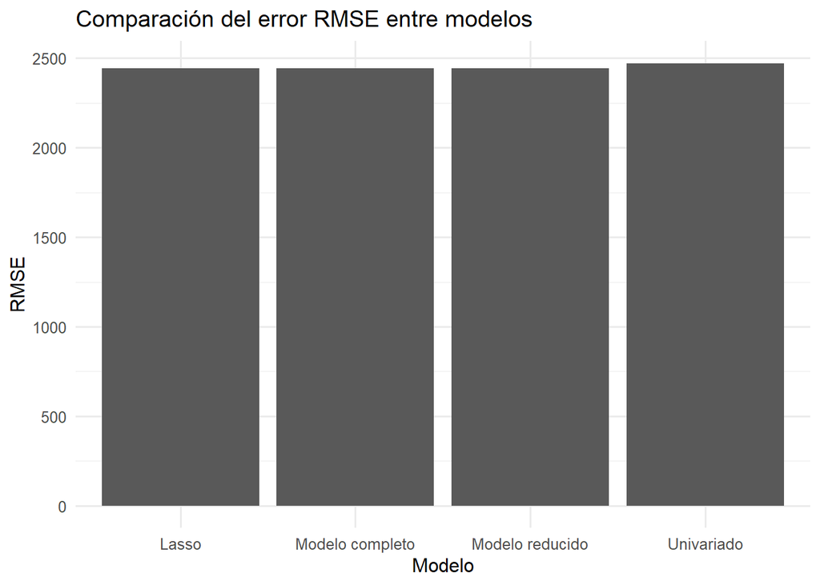

```r
ggplot(results_table, aes(x = Modelo, y = RMSE)) +
  geom_bar(stat = "identity") +
  labs(
    title = "Comparación del error RMSE entre modelos",
    x = "Modelo",
    y = "RMSE"
  )
```

A partir de la evaluación sobre el conjunto de prueba es posible comparar el desempeño de los distintos modelos construidos. El MAE y el RMSE permiten observar el nivel de error promedio de las predicciones, mientras que el R² muestra qué tan bien cada modelo logra explicar la variabilidad del precio de las propiedades.

La comparación entre los modelos permite identificar cuál presenta el mejor balance entre precisión y capacidad de generalización, lo cual será fundamental para seleccionar el modelo más adecuado para la predicción del precio de las viviendas.

# 13 Discusión sobre la efectividad de los modelos

Después de entrenar los diferentes modelos y evaluarlos con el conjunto de prueba, pude comparar cuál de ellos logra predecir mejor el precio de las propiedades. Para hacer esta comparación utilicé las métricas MAE, RMSE y R², que básicamente sirven para medir qué tan lejos están las predicciones del precio real y qué tan bien el modelo logra explicar los datos.

Según pude ver en los resultados, el modelo univariado fue el que peor funcionó. Esto tiene sentido, porque ese modelo solo utiliza una variable para intentar predecir el precio. En un problema como este, el precio de una propiedad depende de muchas cosas al mismo tiempo, como la capacidad del lugar, el número de habitaciones, los baños, el tipo de habitación o incluso la ciudad donde se encuentra. Entonces, tratar de explicar todo eso con una sola variable claramente no es suficiente.

Cuando se usó el modelo completo, el desempeño mejoró un poco. Este modelo utiliza todas las variables numéricas disponibles, por lo que puede capturar más información del conjunto de datos. Sin embargo, según recuerdo de lo visto en clase, usar demasiadas variables también puede causar algunos problemas como multicolinealidad o que el modelo se vuelva demasiado complejo. Aun así, este modelo ya logra reducir el error en comparación con el modelo univariado.

Luego se construyó el modelo reducido, donde se eliminaron algunas variables que no aportaban tanto a la predicción. Según pude ver en las métricas, este modelo fue el que obtuvo el menor RMSE y el mayor valor de R², aunque la diferencia con otros modelos no es muy grande. Aun así, esto sugiere que quitar variables que no ayudan mucho puede mejorar ligeramente la capacidad del modelo para generalizar a nuevos datos.

También se probó un modelo con regularización Lasso, el cual penaliza los coeficientes para evitar que el modelo se vuelva demasiado complejo y para seleccionar automáticamente las variables más importantes. En este caso, el desempeño del modelo Lasso fue muy parecido al del modelo reducido. Según pude observar, esto significa que las variables que se eligieron en el modelo reducido ya eran bastante buenas para explicar el precio, por lo que la regularización no cambió demasiado el resultado final.

Algo que también me llamó la atención es que el R² de todos los modelos es relativamente bajo. Esto probablemente significa que el precio de las propiedades depende de muchos otros factores que no están incluidos en el conjunto de datos. Por ejemplo, podrían influir cosas como la ubicación exacta dentro de la ciudad, las amenidades del alojamiento, la demanda en ciertas temporadas o incluso aspectos como la reputación del anfitrión.

En conclusión, según pude observar en los resultados y en las métricas calculadas, el modelo reducido es el que mejor logra predecir el precio de las propiedades dentro de este conjunto de datos. Aunque ningún modelo explica completamente la variabilidad de los precios, este modelo logra capturar mejor las relaciones presentes en los datos y representa la mejor opción entre los modelos evaluados para este problema.